# Final Project

Group 1

2024-12-07

## Data and Text Mining Final Project: Maximizing Success on YouTube’s Trending Page: Content Optimization Strategies Based on Analysis of the Top 200 Videos Over the Last Four Years

**Topic:** Success Factors on YouTube Trending Videos

**Question:** What are common trends among the top trending YouTube videos in the US, and how do different factors impact their success on the trending page?

**Goal:** To analyze data from each day’s top 200 trending YouTube videos from August 2020 to April 2024 and identify success factors among the most successful videos in the U.S. This analysis will evaluate a video’s success on the trending page based on the following success metrics:

## Libraries

```r
# Libraries / Packages
library(arules)
library(dplyr)
library(ggplot2)
library(ggrepel)
library(grid)
library(gridExtra)
library(jsonlite)
library(kableExtra)
library(knitr)
library(lubridate)
library(purrr)
library(reshape2)
library(stringr)
library(syuzhet)
library(textdata)
library(tidytext)
library(tidyr)
```

## Data Processing, Cleaning, and Unique Video DF Creation

```r
#loading in data
yt <- read.csv("data/US_youtube_trending_data.csv")

#get rid of columns we aren't using
yt$channelId <- NULL
yt$thumbnail_link <- NULL


#normalize the column names
colnames(yt) <- c("video_id", "title", "date_published", "channel_title",
                  "category_id", "date_trending", "tags", "views", "likes",
                  "dislikes", "comments", "comments_disabled", "ratings_disabled",
                  "description")


#turn publishedAt and trending_date to date type
yt$date_published <- ymd_hms(yt$date_published)
yt$date_trending <- ymd_hms(yt$date_trending)


#turn comments_disabled and ratings_disabled to 0s and 1s
disabled_to_binary <- function(x) {
  if (x == "True") {
    return(1)
  } else if (x == "False") {
    return(0)
  } else {
    return(NULL)
  }
}

yt$comments_disabled <- sapply(yt$comments_disabled, disabled_to_binary)
yt$ratings_disabled <- sapply(yt$ratings_disabled, disabled_to_binary)

#separating tags using commas, not |
yt$tags <- gsub("\\|", ",", yt$tags)

#adding the category name
json_data <- fromJSON("data/US_category_id.json")

category_id <- json_data$items$id
category_name <- json_data$items$snippet$title
category_identification <- data.frame(category_id, category_name)

yt_new <- merge(yt, category_identification, by = "category_id", all.x = TRUE)
yt_new$category_id <- NULL

# replacing things with [None] and "" to NA
yt_new$tags[yt_new$tags == "[None]"] <- NA
yt_new$description[yt_new$description == ""] <- NA

#getting rid of videos with 0 views
yt_new <- yt_new[yt_new$views != 0, ]

#get rid of top 3 highest viewed videos (fake views that automatically happened when discord opened)
yt_new <- yt_new[yt_new$views < 628718636, ]

#reordering columns to organize data better
yt_new <- yt_new[c("video_id", "title", "channel_title", "category_name", "description", "tags", "views", "likes", "dislikes", "comments", "date_published", "date_trending", "comments_disabled", "ratings_disabled")]

#naming the final cleaned data frame
video_data <- yt_new
```

```r
# Create unique_video_data with video success metrics

#using dplyr and grouping by video_id to use aggregate functions and calculate success metrics
unique_video_data <- video_data %>%
  group_by(video_id) %>%
  summarize(

    #character data
    video_id = first(video_id),
    title = first(title),
    channel_title = first(channel_title),
    category_name = first(category_name),
    description = first(description),
    tags = first(tags),

    #aggregated data
    max_views = max(views, na.rm = TRUE),
    max_likes = max(likes, na.rm = TRUE),
    max_dislikes = max(dislikes, na.rm = TRUE),
    max_comments = max(comments, na.rm = TRUE),

    #dates
    date_published = first(date_published),
    first_date_trending = min(date_trending),
    last_date_trending = max(date_trending),

    #success metrics
    days_until_trending = as.numeric(as.Date(min(date_trending, na.rm = TRUE)) - as.Date(min(date_published, na.rm = TRUE))),
    trending_retention = as.numeric(max(date_trending, na.rm = TRUE) - min(date_trending, na.rm = TRUE)) + 1,
    engagement_ratio = max((likes + comments) / views, na.rm = TRUE),

    #binary data
    comments_disabled = first(comments_disabled),
    ratings_disabled = first(ratings_disabled)
  ) %>%
  ungroup()
```

## Section 1.1 Descriptive Statistics

Descriptive Statistics Fundamentals (See above, mean, median, mode, etc)

```r
descriptive_stats <- yt_new %>%
  summarise(
    total_videos = n(),
    total_unique_videos = n_distinct(video_id),
    total_views = sum(views, na.rm = TRUE),
    mean_views = round(mean(views, na.rm = TRUE)),
    median_views = median(views, na.rm = TRUE),
    mode_views = as.numeric(names(sort(table(views), decreasing = TRUE)[1])),
    mean_likes = round(mean(likes, na.rm = TRUE)),
    median_likes = median(likes, na.rm = TRUE),
    mode_likes = as.numeric(names(sort(table(likes), decreasing = TRUE)[1])),
    mean_comments = round(mean(comments, na.rm = TRUE)),
    median_comments = median(comments, na.rm = TRUE),
    mode_comments = as.numeric(names(sort(table(comments), decreasing = TRUE)[1]))
  )

category_stats <- yt_new %>%
  group_by(category_name) %>%
  summarise(
    total_videos = n(),
    total_views = sum(views, na.rm = TRUE),
    mean_views = round(mean(views, na.rm = TRUE)),
    median_views = median(views, na.rm = TRUE),
    mode_views = as.numeric(names(sort(table(views), decreasing = TRUE)[1])),
    mean_likes = round(mean(likes, na.rm = TRUE)),
    median_likes = median(likes, na.rm = TRUE),
    mode_likes = as.numeric(names(sort(table(likes), decreasing = TRUE)[1])),
    mean_comments = round(mean(comments, na.rm = TRUE)),
    median_comments = median(comments, na.rm = TRUE),
    mode_comments = as.numeric(names(sort(table(comments), decreasing = TRUE)[1]))
  ) %>%
  arrange(desc(total_videos))

dataset_summary <- function(descriptive_stats, column_name) {
  # Check which column is selected and retrieve the relevant statistics
  if (column_name == "views") {
    mean_value <- descriptive_stats$mean_views
    median_value <- descriptive_stats$median_views
    mode_value <- descriptive_stats$mode_views
  } else if (column_name == "likes") {
    mean_value <- descriptive_stats$mean_likes
    median_value <- descriptive_stats$median_likes
    mode_value <- descriptive_stats$mode_likes
  } else if (column_name == "comments") {
    mean_value <- descriptive_stats$mean_comments
    median_value <- descriptive_stats$median_comments
    mode_value <- descriptive_stats$mode_comments
  } else {
    stop("Invalid column name. Please choose 'views', 'likes', or 'comments'.")
  }

  # Extract common statistics
  total_videos <- descriptive_stats$total_videos
  total_views <- descriptive_stats$total_views

  # print summary
  cat("**Dataset Summary for", column_name, "**\n")
  cat("We looked at", total_videos, "videos in this dataset.\n")
  cat("These videos collectively amassed", total_views, "views.\n")
  cat("The average number of", column_name, "was", mean_value,
      "while the median was", median_value, ".\n")
  cat("The most frequently occurring number of", column_name, "(mode) was", mode_value, ".\n")
}
```

```
## Entire Dataset Stats
```

```
## **Dataset Summary for views **
## We looked at 268704 videos in this dataset.
## These videos collectively amassed 731546546361 views.
## The average number of views was 2722500 while the median was 937255.5 .
## The most frequently occurring number of views (mode) was 214641 .
```

```
## **Dataset Summary for likes **
## We looked at 268704 videos in this dataset.
## These videos collectively amassed 731546546361 views.
## The average number of likes was 131503 while the median was 40214.5 .
## The most frequently occurring number of likes (mode) was 0 .
```

```
## **Dataset Summary for comments **
## We looked at 268704 videos in this dataset.
## These videos collectively amassed 731546546361 views.
## The average number of comments was 10146 while the median was 2755 .
## The most frequently occurring number of comments (mode) was 0 .
```

```
##
## **Descriptive Statistics**
```

Descriptive Statistics of YouTube Dataset

| total_videos | total_unique_videos | total_views | mean_views | median_views | mode_views | mean_likes | median_likes | mode_likes | mean_comments | median_comments | mode_comments |
| --- | --- | --- | --- | --- | --- | --- | --- | --- | --- | --- | --- |
| 268704 | 47124 | 731546546361 | 2722500 | 937255.5 | 214641 | 131503 | 40214.5 | 0 | 10146 | 2755 | 0 |

Descriptive Statistics of YouTube Channel Categories

| category_name | total_videos | total_views | mean_views | median_views | mode_views | mean_likes | median_likes | mode_likes | mean_comments | median_comments | mode_comments |
| --- | --- | --- | --- | --- | --- | --- | --- | --- | --- | --- | --- |
| Entertainment | 53920 | 235887125209 | 4374761 | 1076687.5 | 198683 | 189045 | 46417.0 | 0 | 10064 | 2807.0 | 0 |
| Gaming | 53242 | 89237040850 | 1676065 | 816740.5 | 232026 | 90223 | 37930.5 | 0 | 6762 | 2398.0 | 0 |
| Music | 43383 | 187961685402 | 4332612 | 1390831.0 | 408443 | 270777 | 82018.0 | 0 | 27969 | 4736.0 | 0 |
| Sports | 31327 | 58797298266 | 1876889 | 858367.0 | 269289 | 43335 | 14164.0 | 0 | 3709 | 1937.0 | 0 |
| People & Blogs | 22648 | 39248710818 | 1732988 | 783044.5 | 479346 | 95463 | 39990.0 | 0 | 6316 | 2385.0 | 0 |
| Comedy | 13183 | 20973894330 | 1590980 | 898757.0 | 233071 | 107829 | 60023.0 | 0 | 5618 | 3240.0 | 0 |
| Film & Animation | 10887 | 29869388113 | 2743583 | 1116115.0 | 242753 | 103745 | 53682.0 | 0 | 7334 | 3444.0 | 0 |
| News & Politics | 9669 | 18739069361 | 1938057 | 759183.0 | 144045 | 24833 | 7866.0 | 0 | 5649 | 2541.0 | 0 |
| Science & Technology | 8156 | 22461244247 | 2753953 | 1036726.0 | 416617 | 105724 | 45180.5 | 0 | 5737 | 2707.0 | 0 |
| Howto & Style | 7092 | 8759827539 | 1235170 | 671828.5 | 226743 | 62570 | 37407.5 | 0 | 4590 | 2551.0 | 0 |
| Education | 6650 | 10835449070 | 1629391 | 945303.5 | 334127 | 88454 | 47063.0 | 0 | 5299 | 3218.5 | 0 |
| Autos & Vehicles | 5492 | 5293241454 | 963809 | 651339.5 | 184196 | 43937 | 30216.0 | 0 | 3415 | 2390.0 | 0 |
| Travel & Events | 1713 | 1570697163 | 916928 | 572029.0 | 331199 | 42395 | 26988.0 | 0 | 2549 | 1786.0 | 672 |
| Pets & Animals | 1222 | 1631903665 | 1335437 | 881738.0 | 766471 | 48811 | 38137.5 | 0 | 3170 | 2418.5 | 0 |
| Nonprofits & Activism | 120 | 279970874 | 2333091 | 1190719.5 | 109309 | 106978 | 57552.0 | 0 | 7395 | 3848.5 | 0 |

```
## (Based on the US Trending Page from August 2020 - April 2024)
```

## Section 1.2: Success Metrics Correlation

Is there a correlation between engagement ratio, trending speed, and trending retention among trending YouTube videos?

```r
success_metrics <- unique_video_data %>%
  select(engagement_ratio, days_until_trending, trending_retention) %>%
  na.omit() # Remove rows with NA in these metrics

cat("Number of valid rows for correlation analysis:", nrow(success_metrics), "\n")
```

```
## Number of valid rows for correlation analysis: 47124
```

```r
if (nrow(success_metrics) > 0) {
  # Calculate the Correlation Matrix
  correlation_matrix <- cor(success_metrics, use = "complete.obs")
  print("Correlation Matrix:")
  print(correlation_matrix)

  # Explanation for Correlations
  cat("\n**Success Metrics Correlation Analysis Explanation\n(According to the US Trending Page from August 2020 - April 2024)**\n\n")

  # Helper function to determine the strength of correlation
  get_correlation_strength <- function(correlation_value) {
    if (abs(correlation_value) < 0.2) {
      return("Very Weak or No Correlation")
    } else if (abs(correlation_value) < 0.4) {
      return("Weak Correlation")
    } else if (abs(correlation_value) < 0.6) {
      return("Moderate Correlation")
    } else if (abs(correlation_value) < 0.8) {
      return("Strong Correlation")
    } else {
      return("Very Strong Correlation")
    }
  }

  # Engagement Ratio and Trending Speed
  engagement_trending <- correlation_matrix["engagement_ratio", "days_until_trending"]
  cat("- Engagement Ratio and Trending Speed: ", round(engagement_trending, 3), "\n")
  cat("  - This correlation value suggests the nature and strength of the relationship between how engaged viewers are and how quickly a video trends.\n")
  cat("    Strength of correlation: ", get_correlation_strength(engagement_trending), "\n\n")

  # Engagement Ratio and Trending Retention
  engagement_retention <- correlation_matrix["engagement_ratio", "trending_retention"]
  cat("- Engagement Ratio and Trending Retention: ", round(engagement_retention, 3), "\n")
  cat("  - This value shows whether there is a relationship between viewer engagement and how long a video stays trending.\n")
  cat("    Strength of correlation: ", get_correlation_strength(engagement_retention), "\n\n")

  # Trending Speed and Trending Retention
  trending_retention_speed <- correlation_matrix["days_until_trending", "trending_retention"]
  cat("- Trending Speed and Trending Retention: ", round(trending_retention_speed, 3), "\n")
  cat("  - This indicates whether faster trending videos tend to stay trending for longer periods.\n")
  cat("    Strength of correlation: ", get_correlation_strength(trending_retention_speed), "\n")

} else {
  cat("No valid rows available for correlation analysis.\n")
}
```

```
## [1] "Correlation Matrix:"
##                     engagement_ratio days_until_trending trending_retention
## engagement_ratio          1.00000000          -0.1309861         0.07816825
## days_until_trending      -0.13098608           1.0000000        -0.22097199
## trending_retention        0.07816825          -0.2209720         1.00000000
##
## **Success Metrics Correlation Analysis Explanation
## (According to the US Trending Page from August 2020 - April 2024)**
##
## - Engagement Ratio and Trending Speed:  -0.131
##   - This correlation value suggests the nature and strength of the relationship between how engaged viewers are and how quickly a video trends.
##     Strength of correlation:  Very Weak or No Correlation
##
## - Engagement Ratio and Trending Retention:  0.078
##   - This value shows whether there is a relationship between viewer engagement and how long a video stays trending.
##     Strength of correlation:  Very Weak or No Correlation
##
## - Trending Speed and Trending Retention:  -0.221
##   - This indicates whether faster trending videos tend to stay trending for longer periods.
##     Strength of correlation:  Weak Correlation
```

[output not shown]

## Section 1.3: Most Successful YouTubers in the US based on Trending Success

Who are the most successful YouTubers in the United States, as determined by their total number of unique videos that have reached the trending page, cumulative time spent trending, and average success metrics?

```r
successful_youtubers <- unique_video_data %>%
  group_by(channel_title, category_name) %>%
  summarise(
    total_trending_videos = n(),
    total_time_trending = sum(trending_retention, na.rm = TRUE),
    avg_engagement_ratio = round(mean(engagement_ratio, na.rm = TRUE), 3),
    avg_trending_speed = round(mean(days_until_trending, na.rm = TRUE),),
    avg_trending_retention = round(mean(trending_retention, na.rm = TRUE),2),
    avg_view_count = round(mean(max_views, na.rm = TRUE))
  ) %>%
  arrange(desc(total_trending_videos), desc(total_time_trending))
#Display top 10 most successful categories
top_youtubers <- head(successful_youtubers, 10)
```

Top 10 Most Successful YouTubers:

| channel_title | category_name | total_trending_videos | total_time_trending | avg_engagement_ratio | avg_trending_speed | avg_trending_retention | avg_view_count |
| --- | --- | --- | --- | --- | --- | --- | --- |
| NFL | Sports | 422 | 1844 | 0.015 | 1 | 4.37 | 2632296 |
| NBA | Sports | 396 | 1498 | 0.013 | 1 | 3.78 | 2277646 |
| NBC Sports | Sports | 167 | 813 | 0.016 | 2 | 4.87 | 1315704 |
| ESPN | Sports | 131 | 698 | 0.019 | 1 | 5.33 | 1190753 |
| SSundee | Gaming | 128 | 619 | 0.069 | 1 | 4.84 | 3853133 |
| SSSniperWolf | Entertainment | 115 | 557 | 0.041 | 2 | 4.84 | 5272206 |
| Genshin Impact | Gaming | 105 | 581 | 0.104 | 1 | 5.53 | 2215282 |
| SpaceX | Science & Technology | 105 | 542 | 0.043 | 1 | 5.16 | 1254764 |
| CBS Sports Golazo | Sports | 103 | 530 | 0.013 | 2 | 5.15 | 1015528 |
| The Game Theorists | Gaming | 100 | 665 | 0.079 | 2 | 6.65 | 3477624 |

Are these independent creators or Companies?

```r
# Manually Classifying Channels as Companies or Independent Creators
# Criteria for Classification - Companies are officially owned channels, or YouTube channels that have grown into company / group based effort. If a YouTube channel has a team of people editing it, then it is classified as a Company
# Originally I wanted to classify until I got to at least 10 Companies and 10 independents, but I got to 50 entries before I got to 10 independent creators, which is a conclusion in itself.
manually_classified_creators <- successful_youtubers[1:50,]
manually_classified_creators$creator_type <- c("Company", "Company", "Company", "Company", "Independent", "Independent", "Company", "Company", "Company", "Company", "Company", "Independent", "Company", "Company", "Company", "Company", "Company", "Company", "Company", "Company", "Company","Company", "Company", "Company", "Company", "Company", "Company", "Company", "Company", "Company", "Company","Company", "Company", "Company", "Company", "Company", "Company", "Independent", "Company", "Independent", "Company", "Company", "Independent", "Independent", "Company", "Company", "Company", "Company", "Company", "Company")

creator_summary <- manually_classified_creators %>%
  group_by(creator_type) %>%
  summarise(
    total_creators = n(),
    avg_trending_videos = round(mean(total_trending_videos, na.rm = TRUE)),
    avg_time_trending = round(mean(total_time_trending, na.rm = TRUE)),
    avg_engagement_ratio = round(mean(avg_engagement_ratio, na.rm = TRUE),3)
  )

#Display the top 25 creators, but this time with Creator Classification
manually_classified_creators <- manually_classified_creators[1:25,]
```

Top 25 Most Successful YouTubers with Creator Classification:

| channel_title | category_name | total_trending_videos | total_time_trending | avg_engagement_ratio | avg_trending_speed | avg_trending_retention | avg_view_count | creator_type |
| --- | --- | --- | --- | --- | --- | --- | --- | --- |
| NFL | Sports | 422 | 1844 | 0.015 | 1 | 4.37 | 2632296 | Company |
| NBA | Sports | 396 | 1498 | 0.013 | 1 | 3.78 | 2277646 | Company |
| NBC Sports | Sports | 167 | 813 | 0.016 | 2 | 4.87 | 1315704 | Company |
| ESPN | Sports | 131 | 698 | 0.019 | 1 | 5.33 | 1190753 | Company |
| SSundee | Gaming | 128 | 619 | 0.069 | 1 | 4.84 | 3853133 | Independent |
| SSSniperWolf | Entertainment | 115 | 557 | 0.041 | 2 | 4.84 | 5272206 | Independent |
| Genshin Impact | Gaming | 105 | 581 | 0.104 | 1 | 5.53 | 2215282 | Company |
| SpaceX | Science & Technology | 105 | 542 | 0.043 | 1 | 5.16 | 1254764 | Company |
| CBS Sports Golazo | Sports | 103 | 530 | 0.013 | 2 | 5.15 | 1015528 | Company |
| The Game Theorists | Gaming | 100 | 665 | 0.079 | 2 | 6.65 | 3477624 | Company |
| Fortnite | Gaming | 97 | 570 | 0.058 | 1 | 5.88 | 3776815 | Company |
| Ryan Trahan | Entertainment | 97 | 554 | 0.062 | 1 | 5.71 | 5123139 | Independent |
| ESPN FC | Sports | 97 | 513 | 0.016 | 2 | 5.29 | 876904 | Company |
| JYP Entertainment | Music | 95 | 579 | 0.163 | 1 | 6.09 | 17323731 | Company |
| HYBE LABELS | Music | 94 | 611 | 0.185 | 1 | 6.50 | 23887727 | Company |
| NBA on TNT | Sports | 94 | 455 | 0.017 | 1 | 4.84 | 998975 | Company |
| First We Feast | Entertainment | 93 | 609 | 0.056 | 1 | 6.55 | 2909541 | Company |
| WWE | Sports | 92 | 510 | 0.033 | 1 | 5.54 | 3112572 | Company |
| FOX Soccer | Sports | 91 | 347 | 0.012 | 2 | 3.81 | 1578027 | Company |
| Apex Legends | Gaming | 90 | 570 | 0.055 | 1 | 6.33 | 2585281 | Company |
| Dude Perfect | Sports | 89 | 684 | 0.056 | 1 | 7.69 | 7739728 | Company |
| FORMULA 1 | Sports | 89 | 497 | 0.028 | 1 | 5.58 | 4569954 | Company |
| SMTOWN | Music | 88 | 542 | 0.159 | 1 | 6.16 | 19717985 | Company |
| BANGTANTV | Music | 88 | 481 | 0.225 | 1 | 5.47 | 9739265 | Company |
| Marvel Entertainment | Entertainment | 86 | 596 | 0.056 | 1 | 6.93 | 9449186 | Company |

Independent Creators vs Companies Summary (Top 50 Creators)

| creator_type | total_creators | avg_trending_videos | avg_time_trending | avg_engagement_ratio |
| --- | --- | --- | --- | --- |
| Company | 43 | 102 | 581 | 0.059 |
| Independent | 7 | 90 | 492 | 0.067 |

## Section 1.4: Most Successful Channel Categories in the US based on Trending Success

What are the most successful channel categories in the United States, as determined by total number of unique videos that have reached the trending page, cumulative time spent trending, and average success metrics?

```r
successful_categories <- unique_video_data %>%
  group_by(category_name,) %>%
  summarise(
    total_trending_videos = n(),
    total_time_trending = sum(trending_retention, na.rm = TRUE),
    avg_engagement_ratio = round(mean(engagement_ratio, na.rm = TRUE), 3),
    avg_trending_speed = round(mean(days_until_trending, na.rm = TRUE), 2),
    avg_trending_retention = round(mean(trending_retention, na.rm = TRUE), 2),
    avg_view_count = round(mean(max_views, na.rm = TRUE))
  ) %>%
  arrange(desc(total_trending_videos), desc(total_time_trending))
```

Summary of Channel Category Success:

| category_name | total_trending_videos | total_time_trending | avg_engagement_ratio | avg_trending_speed | avg_trending_retention | avg_view_count |
| --- | --- | --- | --- | --- | --- | --- |
| Gaming | 9436 | 53222 | 0.064 | 1.47 | 5.64 | 1744865 |
| Entertainment | 9181 | 54535 | 0.063 | 1.52 | 5.94 | 3438793 |
| Music | 7349 | 44802 | 0.105 | 1.40 | 6.10 | 4918012 |
| Sports | 6073 | 31836 | 0.025 | 1.43 | 5.24 | 1668339 |
| People & Blogs | 4034 | 22804 | 0.078 | 1.63 | 5.65 | 1977235 |
| Comedy | 2251 | 13171 | 0.092 | 1.56 | 5.85 | 1744120 |
| Film & Animation | 1833 | 11038 | 0.072 | 1.44 | 6.02 | 3089241 |
| News & Politics | 1730 | 10070 | 0.020 | 1.54 | 5.82 | 1442663 |
| Science & Technology | 1423 | 8212 | 0.055 | 1.46 | 5.77 | 2971341 |
| Howto & Style | 1216 | 7087 | 0.073 | 1.55 | 5.83 | 1510762 |
| Education | 1113 | 6630 | 0.073 | 1.44 | 5.96 | 1978680 |
| Autos & Vehicles | 967 | 5499 | 0.062 | 1.43 | 5.69 | 1128668 |
| Travel & Events | 292 | 1709 | 0.062 | 1.41 | 5.85 | 1142784 |
| Pets & Animals | 207 | 1222 | 0.064 | 1.60 | 5.90 | 1645282 |
| Nonprofits & Activism | 19 | 122 | 0.099 | 1.32 | 6.42 | 2038574 |

## Section 1.5: Descriptive Statistics Visualizations

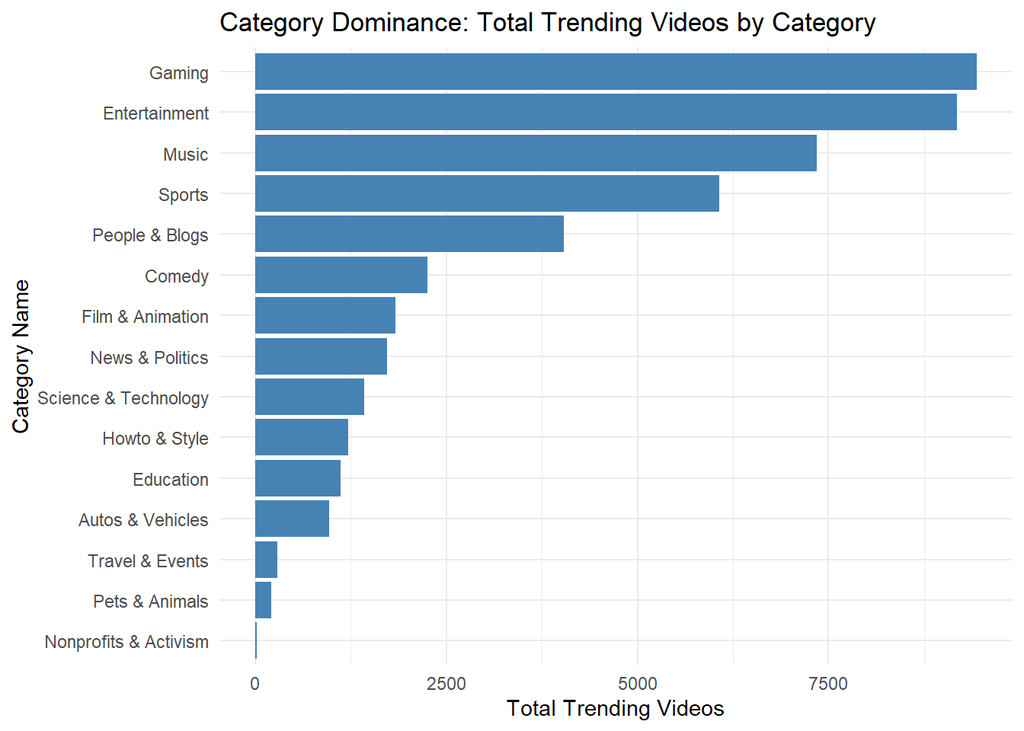

```r
category_metrics <- unique_video_data %>%
  group_by(category_name) %>%
  summarise(
    total_trending_videos = n(),
    avg_view_count = round(mean(max_views, na.rm = TRUE)),
    avg_engagement_ratio = round(mean(engagement_ratio, na.rm = TRUE),3),
    avg_trending_speed = round(mean(days_until_trending, na.rm = TRUE),2),
    avg_trending_retention = round(mean(trending_retention, na.rm = TRUE),2),
    total_time_trending = sum(trending_retention, na.rm = TRUE)
  ) %>%
  arrange(desc(total_trending_videos))

#Visualization 1 Bar Chart for Category Dominance
bar_chart <- ggplot(category_metrics, aes(x = reorder(category_name, total_trending_videos), y = total_trending_videos)) +
  geom_bar(stat = "identity", fill = "steelblue") +
  coord_flip() +
  labs(
    title = "Category Dominance: Total Trending Videos by Category",
    x = "Category Name",
    y = "Total Trending Videos"
  ) +
  theme_minimal()
print(bar_chart)
```

```r
cat("**Explanation**: This bar chart shows the total number of trending videos for each category, highlighting which categories dominate the trending page.\n\n")
```

```
## **Explanation**: This bar chart shows the total number of trending videos for each category, highlighting which categories dominate the trending page.
```

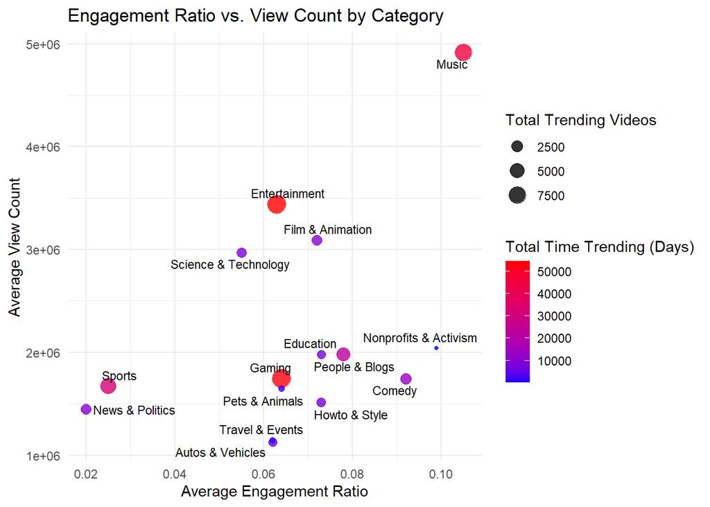

```r
#Visualization 2 Grouped Bar Chart for Overall Success
engagement_vs_views <- ggplot(category_metrics, aes(x = avg_engagement_ratio, y = avg_view_count, label = category_name)) +
  geom_point(aes(size = total_trending_videos, color = total_time_trending), alpha = 0.8) +
  scale_color_gradient(low = "blue", high = "red") +
  geom_text_repel(size = 3) +
  labs(
    title = "Engagement Ratio vs. View Count by Category",
    x = "Average Engagement Ratio",
    y = "Average View Count",
    size = "Total Trending Videos",
    color = "Total Time Trending (Days)"
  ) +
  theme_minimal()

print(engagement_vs_views)
```

```r
cat("**Explanation**: This scatter plot compares average engagement ratios and view counts for each category. Categories are sized by their total number of trending videos and colored by total time spent trending.\n\n")
```

```
## **Explanation**: This scatter plot compares average engagement ratios and view counts for each category. Categories are sized by their total number of trending videos and colored by total time spent trending.
```

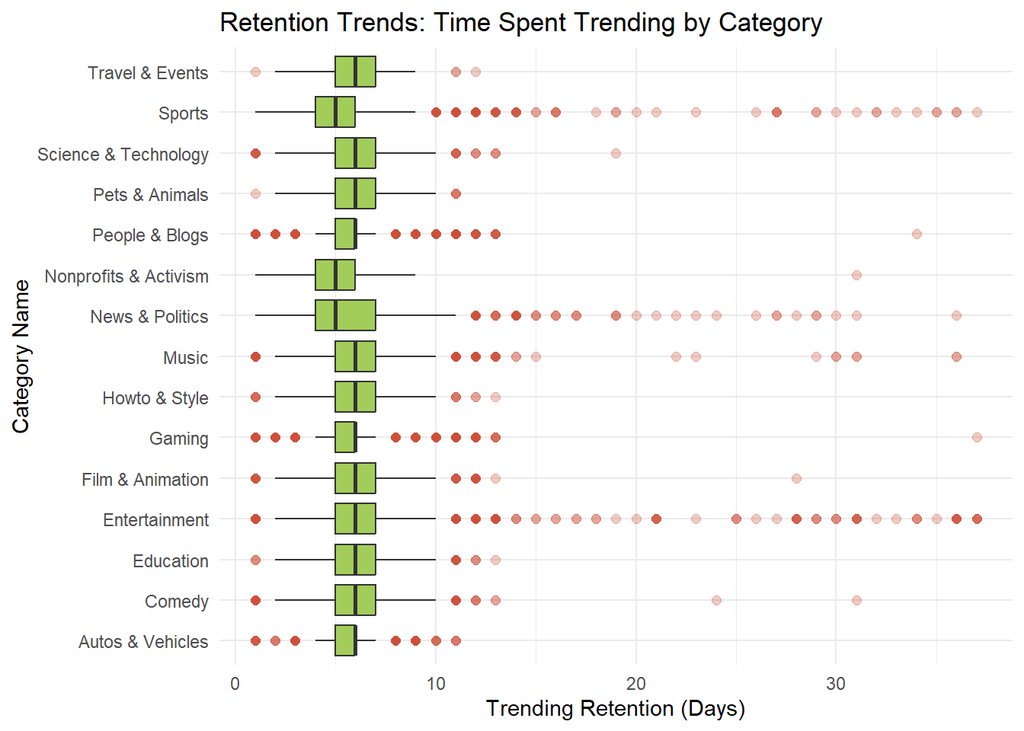

```r
#Visualization 3 Boxplots
ggplot(unique_video_data, aes(x = category_name, y = trending_retention)) +
  geom_boxplot(fill = "darkolivegreen3", outlier.alpha = 0.3, outlier.color = "tomato3", outlier.size = 2) +
  coord_flip() +
  labs(
    title = "Retention Trends: Time Spent Trending by Category",
    x = "Category Name",
    y = "Trending Retention (Days)"
  ) +
  theme_minimal()
```

```r
cat("**Explanation**: This boxplot shows the spread of time videos spend trending for each category, identifying categories with consistent or highly variable retention times.\n\n")
```

```
## **Explanation**: This boxplot shows the spread of time videos spend trending for each category, identifying categories with consistent or highly variable retention times.
```

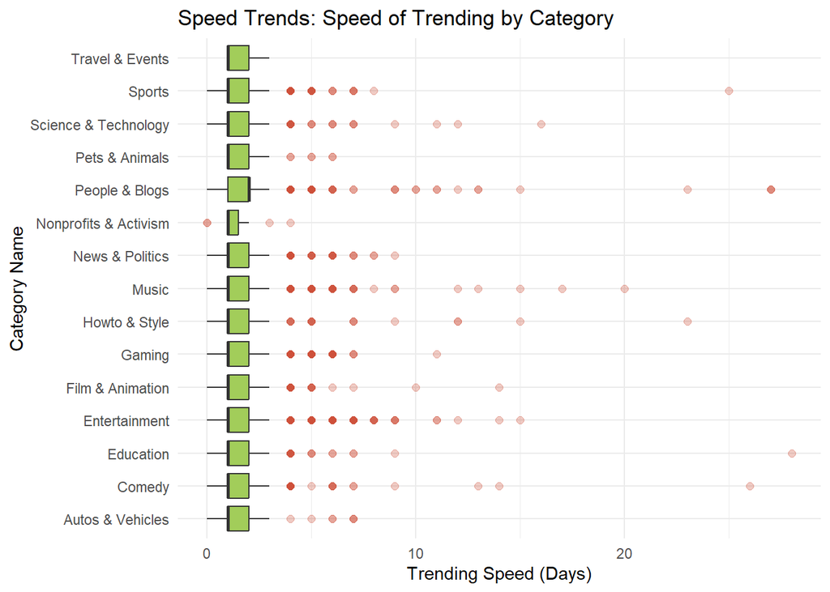

```r
ggplot(unique_video_data, aes(x = category_name, y = days_until_trending)) +
  geom_boxplot(fill = "darkolivegreen3", outlier.alpha = 0.3, outlier.color = "tomato3", outlier.size = 2) +
  coord_flip() +
  labs(
    title = "Speed Trends: Speed of Trending by Category",
    x = "Category Name",
    y = "Trending Speed (Days)"
  ) +
  theme_minimal()
```

```r
cat("**Explanation**: This boxplot shows the spread of the speed of videos reaching the trending page trending for each category, identifying categories with consistent or highly variable trending speed times.\n\n")
```

```
## **Explanation**: This boxplot shows the spread of the speed of videos reaching the trending page trending for each category, identifying categories with consistent or highly variable trending speed times.
```

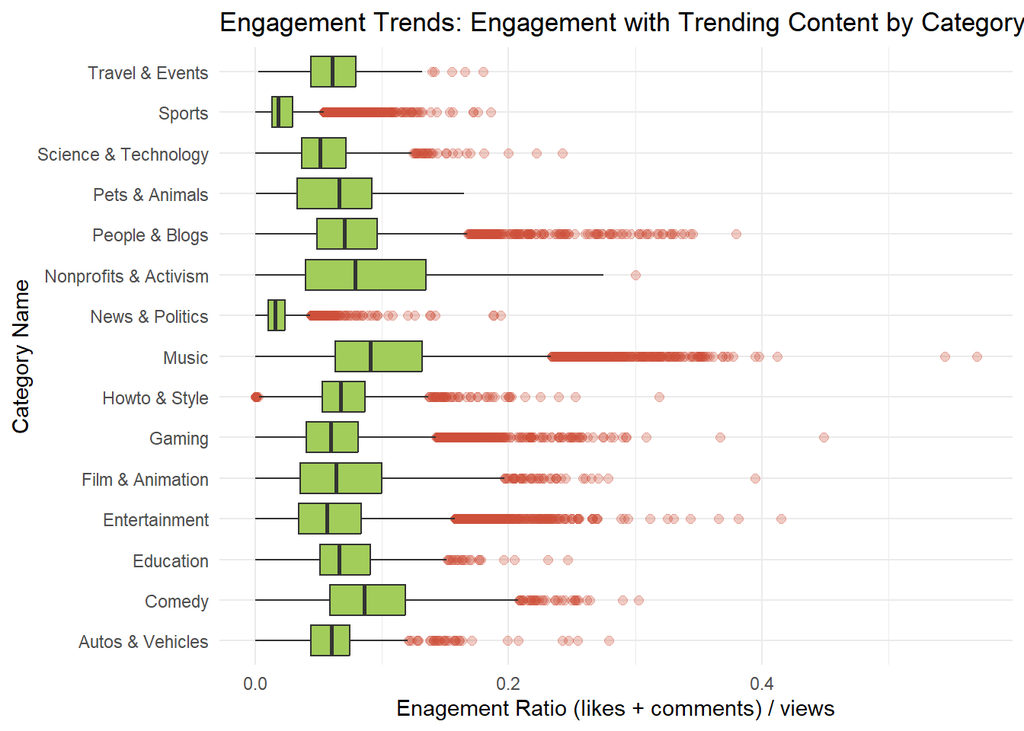

```r
ggplot(unique_video_data, aes(x = category_name, y = engagement_ratio)) +
  geom_boxplot(fill = "darkolivegreen3", outlier.alpha = 0.3, outlier.color = "tomato3", outlier.size = 2) +
  coord_flip() +
  labs(
    title = "Engagement Trends: Engagement with Trending Content by Category",
    x = "Category Name",
    y = "Enagement Ratio (likes + comments) / views"
  ) +
  theme_minimal()
```

```r
cat("**Explanation**: This boxplot shows the spread of engagement with trending content for each category, identifying categories with consistent or highly variable engagement ratios. ")
```

```
## **Explanation**: This boxplot shows the spread of engagement with trending content for each category, identifying categories with consistent or highly variable engagement ratios.
```

[output not shown]

## Section 2.1: Sentiment Analysis

Due to data constraints, we used the video description to determine a video’s overall sentiment. While this method provided valuable insights into how a video’s sentiment impacts video success, it is a limitation, as video descriptions may not full repersent the overall emotional tone of the entire video.

What are the average success metrics depending on video’s dominant sentiments?

```r
yt_new_description <- tibble(text = str_to_lower(unique_video_data$description))

#replace NA
yt_new_description[is.na(yt_new_description)] <- ""

#find the emotions based on description
emotions <- get_nrc_sentiment(yt_new_description$text)#find the emotions per entry

yt_new_description <- cbind(yt_new_description, emotions) #merges emotions table with description dataframe

# Summarize the number of items (count) per emotion column
emo_sum <- emotions %>%
  summarise(across(everything(), sum, na.rm = TRUE)) %>%
  pivot_longer(everything(), names_to = "emotion", values_to = "count")

yt_new_description <- cbind(unique_video_data, yt_new_description)
yt_new_description <- yt_new_description[,-5] # Delete the original Description column
```

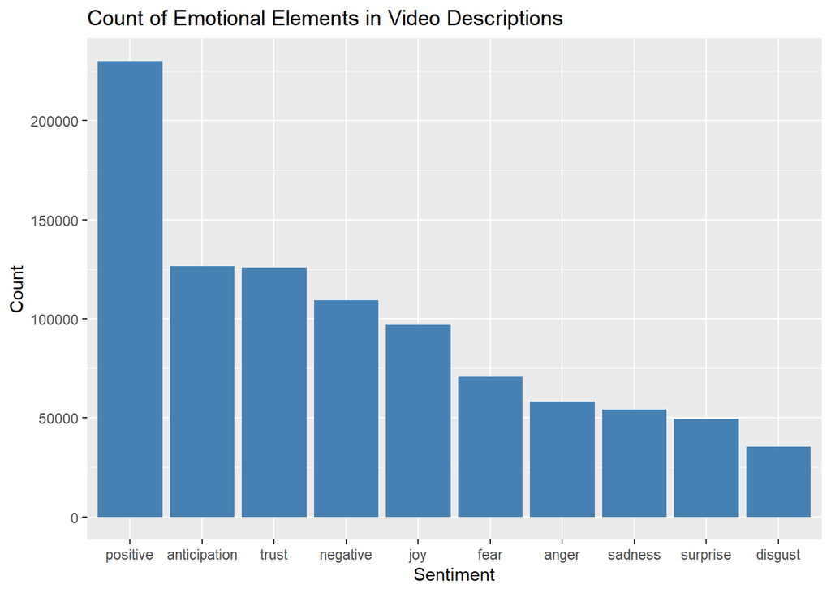

```r
# Calculate average success metrics by dominant sentiment
yt_new_description$dominant_sentiment <- apply(emotions, 1, function(x) {
  max_value <- max(x)
  if (max_value == 0) {
    return("no sentiment/\nno description")
  } else {
    return(names(x)[which.max(x)])
  }
})

average_description_sentiment <- yt_new_description %>%
  group_by(dominant_sentiment) %>%
  summarise(
    total_videos = n(),
    avg_trending_speed = round(mean(days_until_trending),2),
    avg_trending_retention = round(mean(trending_retention),2),
    avg_engagement_ratio = round(mean(engagement_ratio), 3)
  ) %>%
  arrange(desc(total_videos))

#Count of Emotional Elements in Video Descriptions
ggplot(emo_sum, aes(x = reorder(emotion, -count), y = count)) +
  geom_bar(stat = 'identity', fill = "steelblue") +
  labs(title = "Count of Emotional Elements in Video Descriptions", x = "Sentiment", y = "Count")
```

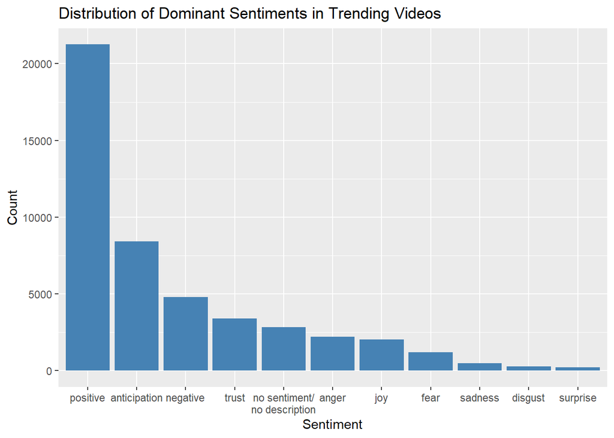

```r
#Distribution of Dominant Sentiments across Trending Videos
ggplot(average_description_sentiment, aes(x = reorder(dominant_sentiment, -total_videos), y = total_videos)) +
  geom_bar(stat = 'identity', fill = "steelblue") +
  labs(title = "Distribution of Dominant Sentiments in Trending Videos", x = "Sentiment", y = "Count")
```

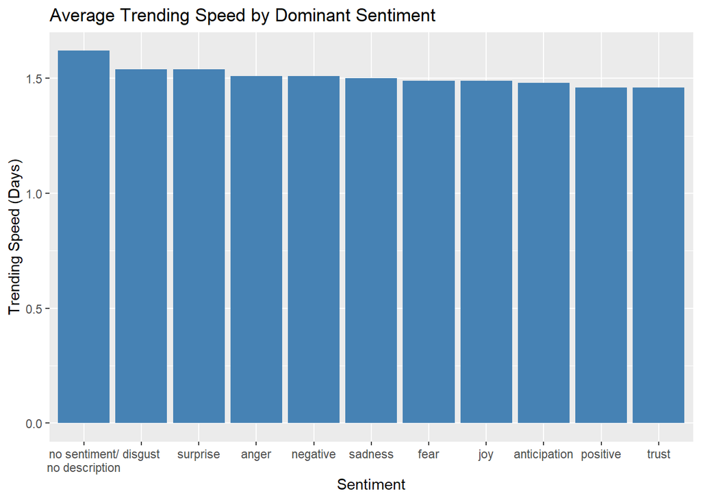

```r
# Average views by dominant sentiment
ggplot(average_description_sentiment, aes(x = reorder(dominant_sentiment, -avg_trending_speed), y = avg_trending_speed)) +
  geom_bar(stat = 'identity', fill = "steelblue") +
  labs(title = "Average Trending Speed by Dominant Sentiment", x = "Sentiment", y = "Trending Speed (Days)")
```

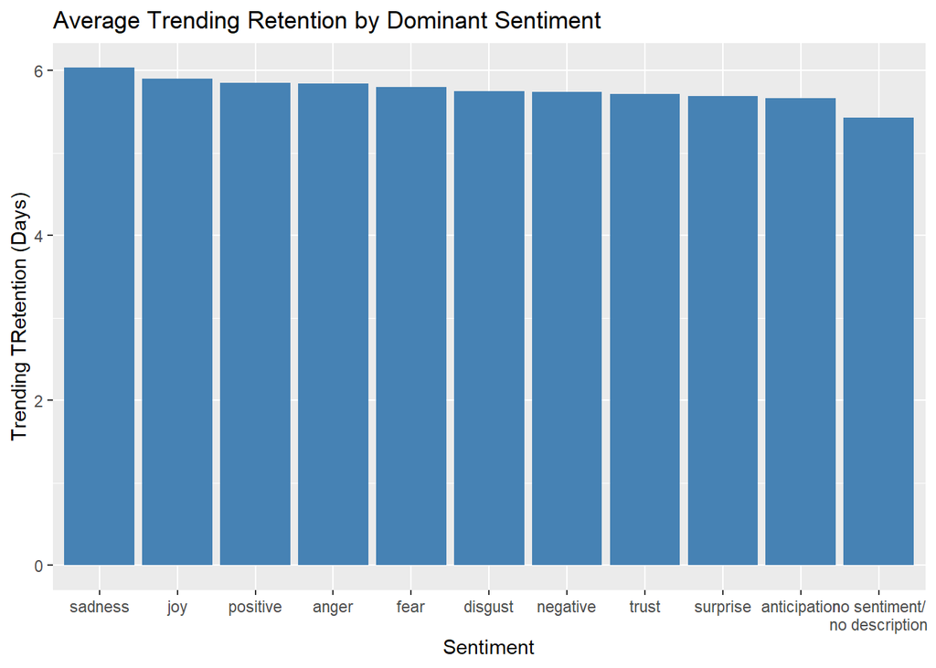

```r
# Average likes by dominant sentiment
ggplot(average_description_sentiment, aes(x = reorder(dominant_sentiment, -avg_trending_retention), y = avg_trending_retention)) +
  geom_bar(stat = 'identity', fill = "steelblue") +
  labs(title = "Average Trending Retention by Dominant Sentiment", x = "Sentiment", y = "Trending TRetention (Days)")
```

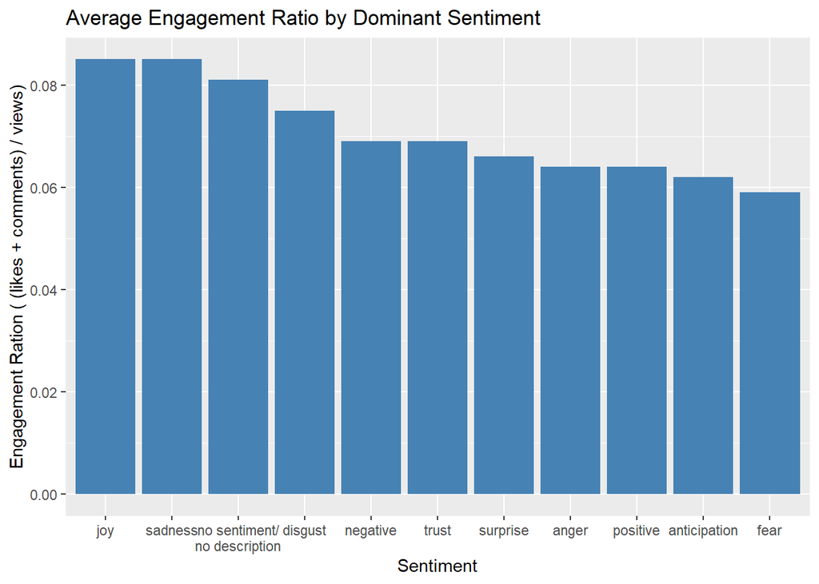

Dominant Sentiment Average Success Metrics

[output not shown]

[output not shown]

```r
# Average comments by dominant sentiment
ggplot(average_description_sentiment, aes(x = reorder(dominant_sentiment, -avg_engagement_ratio), y = avg_engagement_ratio)) +
  geom_bar(stat = 'identity', fill = "steelblue") +
  labs(title = "Average Engagement Ratio by Dominant Sentiment", x = "Sentiment", y = "Engagement Ration ( (likes + comments) / views)")
```

## Section 2.2: Dominant Sentiment Correlation with Success

Do video sentiments have a statistically significant impact on success metrics? (T-Test / ANOVA hypothesis test)

```
##
## **ANOVA Hypothese:**
##  Null Hypothesis (H0): There is no significane difference in success metrics between dominant sentiments.
## Alternative Hypothesis (H1): There is significane difference in success metrics between dominant sentiments.
```

```r
#Engagement Ratio ANOVA
engage_aov <- aov(engagement_ratio ~ dominant_sentiment, data = yt_new_description)
summary(engage_aov)
```

```
##                       Df Sum Sq Mean Sq F value Pr(>F)
## dominant_sentiment    10   1.93 0.19286   85.17 <2e-16 ***
## Residuals          47113 106.69 0.00226
## ---
## Signif. codes:  0 '***' 0.001 '**' 0.01 '*' 0.05 '.' 0.1 ' ' 1
```

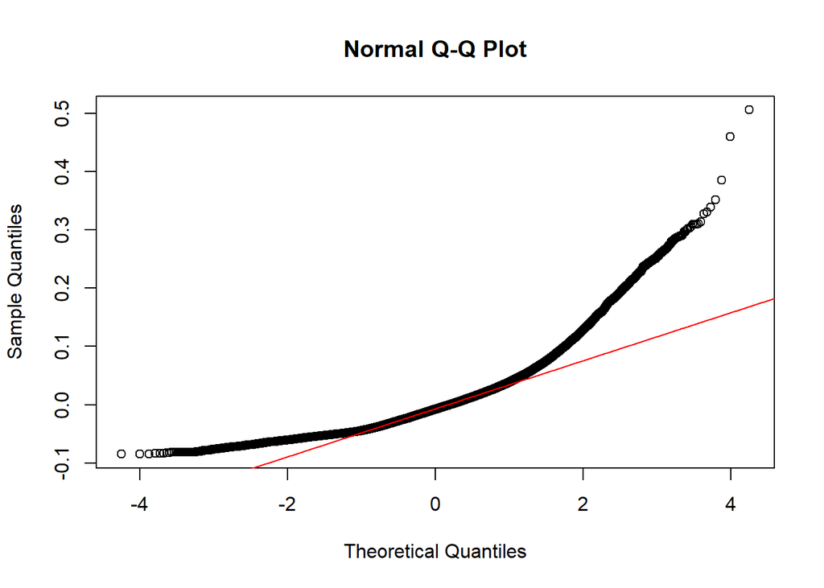

```r
# Get residuals from the ANOVA model
residuals <- residuals(engage_aov)
# Q-Q plot to check normality visually
qqnorm(residuals)
qqline(residuals, col = "red")
```

```r
#Trending Speed ANOVA
speed_aov <- aov(days_until_trending ~ dominant_sentiment, data = yt_new_description)
summary(speed_aov)
```

```
##                       Df Sum Sq Mean Sq F value   Pr(>F)
## dominant_sentiment    10     68   6.842   9.571 4.09e-16 ***
## Residuals          47113  33678   0.715
## ---
## Signif. codes:  0 '***' 0.001 '**' 0.01 '*' 0.05 '.' 0.1 ' ' 1
```

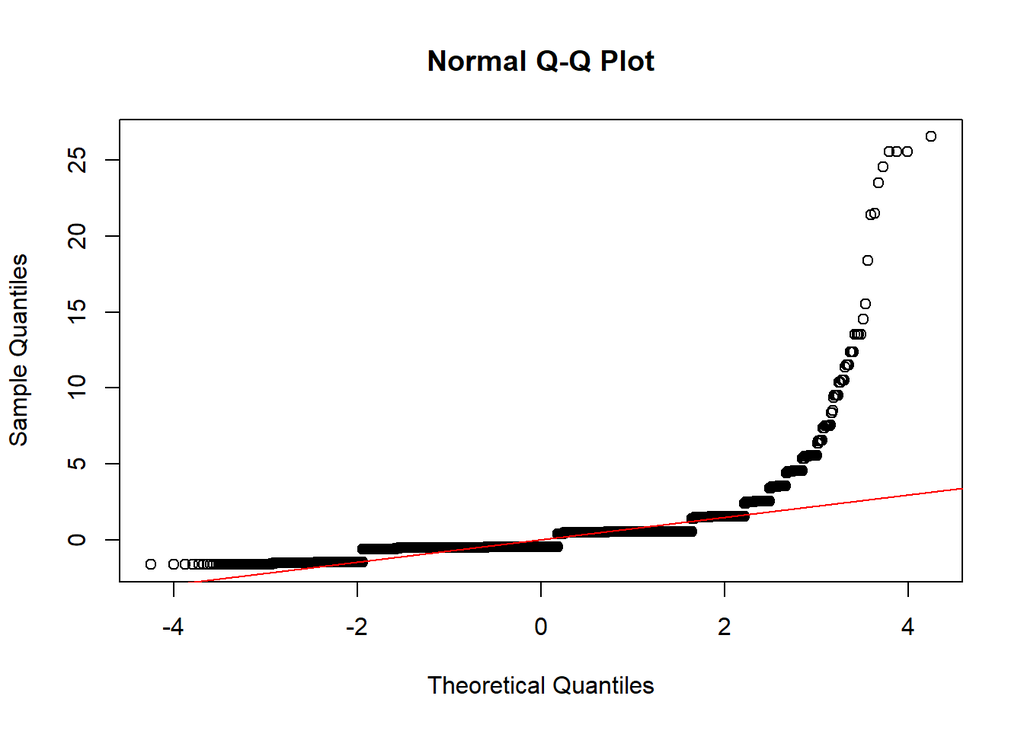

```r
# Get residuals from the ANOVA model
residuals <- residuals(speed_aov)
# Q-Q plot to check normality visually
qqnorm(residuals)
qqline(residuals, col = "red")
```

```r
#Trending Retention ANOVA
retention_aov <- aov(trending_retention ~ dominant_sentiment, data = yt_new_description)
summary(retention_aov)
```

```
##                       Df Sum Sq Mean Sq F value Pr(>F)
## dominant_sentiment    10    662   66.23   16.71 <2e-16 ***
## Residuals          47113 186710    3.96
## ---
## Signif. codes:  0 '***' 0.001 '**' 0.01 '*' 0.05 '.' 0.1 ' ' 1
```

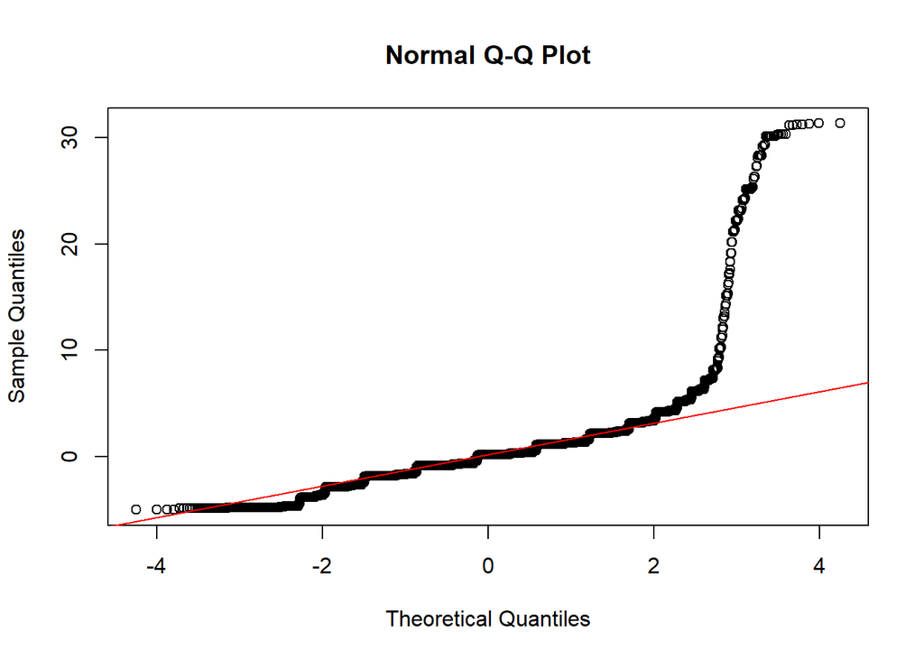

[output not shown]

```r
# Get residuals from the ANOVA model
residuals <- residuals(retention_aov)
# Q-Q plot to check normality visually
qqnorm(residuals)
qqline(residuals, col = "red")
```

## Section 2.3: Dominant Sentiment Frequency

Are trending videos more commonly positive, negative, or associated with other emotions?

```r
video_sentiment_counts <- yt_new_description %>%
  group_by(dominant_sentiment) %>%
  summarise(
    video_count = n()
  )%>%
  arrange(desc(video_count)) %>%
  slice_max(order_by = video_count, n = 5)
```

Dominant Sentiment Seen on the Trending Page

[output not shown]

[output not shown]

## Section 2.4: Dominant Sentiment per Channel Category

Do trending videos in certain channel categories lean to specific sentiments?

```r
category_sentiment_counts <- yt_new_description %>%
  group_by(category_name, dominant_sentiment) %>%
  summarise(
    video_count = n()
  )%>%
  slice_max(order_by = video_count, n = 2) %>%
  arrange(category_name, desc(video_count))
```

Top 2 Dominant Sentiments per Channel Cateogry

| category_name | dominant_sentiment | video_count |
| --- | --- | --- |
| Autos & Vehicles | positive | 518 |
| Autos & Vehicles | anticipation | 154 |
| Comedy | positive | 905 |
| Comedy | anticipation | 392 |
| Education | positive | 775 |
| Education | anticipation | 93 |
| Entertainment | positive | 4421 |
| Entertainment | anticipation | 1766 |
| Film & Animation | positive | 942 |
| Film & Animation | anticipation | 308 |
| Gaming | positive | 3890 |
| Gaming | negative | 1996 |
| Howto & Style | positive | 806 |
| Howto & Style | anticipation | 201 |
| Music | positive | 2924 |
| Music | joy | 1044 |
| News & Politics | positive | 637 |
| News & Politics | anticipation | 270 |
| Nonprofits & Activism | positive | 15 |
| Nonprofits & Activism | anticipation | 2 |
| People & Blogs | positive | 1515 |
| People & Blogs | anticipation | 813 |
| Pets & Animals | positive | 119 |
| Pets & Animals | anticipation | 29 |
| Science & Technology | positive | 966 |
| Science & Technology | anticipation | 186 |
| Sports | positive | 2594 |
| Sports | anticipation | 1779 |
| Travel & Events | positive | 219 |
| Travel & Events | anticipation | 29 |

[output not shown]

## Section 2.5: Sentiment Analysis Conclusions

What are the overall sentiments of each Unique Video in the dataset? (Add Output to Unique.Video_DF) What are the conclusions from the Sentiment Analysis?

```r
# Add Overall Video Sentiment to Unique.video_df
unique_video_data$dominant_sentiment <- yt_new_description$dominant_sentiment
```

[output not shown]

## Section 3.1: Association Mining Data Prep

The arules algorithm works best with categorical data, therefore, for this section of the project, success metrics had to be classified into categorical values to enable meaningful association mining. This analysis used Tertile-Based Categorization due to the large amount of outliers identified in each success metric in Section 1.5

[output not shown]

```r
# Determining what the cutoffs for the Tertitle categorization
tertile_cutoffs_speed <- quantile(unique_video_data$days_until_trending, probs = c(0, 1/3, 2/3, 1))
print(tertile_cutoffs_speed)
```

```
##        0% 33.33333% 66.66667%      100%
##         0         1         2        28
```

```r
tertile_cutoffs_reten <- quantile(unique_video_data$trending_retention, probs = c(0, 1/3, 2/3, 1))
print(tertile_cutoffs_reten)
```

```
##        0% 33.33333% 66.66667%      100%
##         1         5         6        37
```

```r
tertile_cutoffs_engage <- quantile(unique_video_data$engagement_ratio, probs = c(0, 1/3, 2/3, 1))
print(tertile_cutoffs_engage)
```

```
##         0%  33.33333%  66.66667%       100%
## 0.00000000 0.04130532 0.07651958 0.56947307
```

```r
arules_df <- unique_video_data %>%
  mutate(
    # Create categories based on Tertiles
    days_until_trending_category = ntile(days_until_trending, 3),
    trending_retention_category = ntile(trending_retention, 3),
    engagement_ratio_category = ntile(engagement_ratio, 3),

    # Recode categories into descriptive labels
    days_until_trending_category = case_when(
      days_until_trending_category == 1 ~ "Good",
      days_until_trending_category == 2 ~ "Mid",
      days_until_trending_category == 3 ~ "Poor"),
    trending_retention_category = case_when(
      trending_retention_category == 1 ~ "Poor",
      trending_retention_category == 2 ~ "Mid",
      trending_retention_category == 3 ~ "Good"),
    engagement_ratio_category = case_when(
      engagement_ratio_category == 1 ~ "Poor",
      engagement_ratio_category == 2 ~ "Mid",
      engagement_ratio_category == 3 ~ "Good"),

    # Normalize the metrics
    days_until_trending_scaled = (1 - (days_until_trending /
                                        max(days_until_trending, na.rm = TRUE))),
    trending_retention_scaled = (trending_retention / max(trending_retention, na.rm = TRUE)),
    engagement_ratio_scaled = (engagement_ratio / max(engagement_ratio, na.rm = TRUE)),

    # Calculate success score into a single variable, giving equal weight to all success metrics
    success_score = (1/3) * days_until_trending_scaled +
                    (1/3) * trending_retention_scaled +
                    (1/3) * engagement_ratio_scaled
  ) %>%
  mutate(
    # Categorize overall success based on the success score
    overall_success = ntile(success_score, 3),
    overall_success = case_when(
      overall_success == 1 ~ "Poor",
      overall_success == 2 ~ "Mid",
      overall_success == 3 ~ "Good")
  )


# Initialize the final rules tables data.frame
Good.rules_table <- data.frame(
  rules =character(),
  support = numeric(),
  confidence = numeric(),
  coverage = numeric(),
  lift = numeric(),
  count = integer()
)[0, ]

Poor.rules_table <- data.frame(
  rules =character(),
  support = numeric(),
  confidence = numeric(),
  coverage = numeric(),
  lift = numeric(),
  count = integer()
)[0, ]

# Intialize a function to facilitate rules plotting
am_plot <- function(df1, df2, metric, eval1, eval2, test) {
  a <- min(df1$support, df2$support)
  b = max(df1$support, df2$support)

  c <- min(df1$lift, df2$lift)
  d <- max(df1$lift, df2$lift)

  p1 <- ggplot(df1, aes(x = support, y = lift, color = confidence)) +
    geom_point(size = 8, alpha = 0.75) +  # Adjusted size for better visualization
    scale_color_gradient2(low = "tomato3", mid = "tan1", high = "darkolivegreen3",
                          midpoint = 0.6, name = "Confidence") +
    theme_light() +
    labs(
      x = "Support",
      y = "Lift",
      subtitle = paste("Where", metric,  "=", eval1)) +
    xlim(a,b) + ylim(c,d)

  p2 <- ggplot(df2, aes(x = support, y = lift, color = confidence)) +
    geom_point(size = 8, alpha = 0.75) +  # Adjusted size for better visualization
    scale_color_gradient2(low = "tomato3", mid = "tan1", high = "darkolivegreen3",
                          midpoint = 0.6, name = "Confidence") +
    theme_light() +
    labs(
      x = "Support",
      y = "Lift",
      subtitle = paste("Where", metric,  "=", eval2)) +
    xlim(a,b) + ylim(c,d)

  p <- grid.arrange(
    p1, p2,
    ncol = 2,
    top = textGrob(paste("Association Mining on Youtube Trending", test))
    )

  return(p)
}

# Initialize a function to clean the outputted rules tables
clean_rules_tables <- function (df) {
  metrics <- c("overall_success", "days_until_trending_category", "trending_retention_category", "engagement_ratio_category")

df <- df %>%
  mutate(
    # Create a new column that reports the channel category of each rule
    category = map_chr(rules, ~ {
      # Check for matches of category_name phrases in the 'rules' text
       matched_phrase <- purrr::detect(category_name, function(cat) str_detect(.x, fixed(cat)))
      # If a match is found, return it; otherwise, return NA
      ifelse(length(matched_phrase) > 0, matched_phrase, NA_character_)
    }),
    metric = map_chr(rules, ~ {
      matched_phrase <- purrr::detect(metrics, function(cat) str_detect(.x, fixed(cat)))
      ifelse(length(matched_phrase) > 0, matched_phrase, NA_character_)
    })
  ) %>%
  group_by(category, metric) %>%
  slice_max(order_by = confidence, n = 3) %>%
  filter(confidence > 0.7) %>%
  arrange(category, desc(confidence))

return(df)
}
```

## Section 3.2: Length of User Set Descriptive Variables Associations

Are the lengths of user set descriptive variables (title, description, and tags) associated with better success metrics?

Data Prep and Function Creation:

```r
# Calculate the number of tags and categorize tag usage without expanding rows
am.1_df <- arules_df %>%
  mutate(
    # Calculate the number of tags for each video (count of comma-separated tags)
    tag_usage = str_count(tags, ",") + 1,  # str_count counts commas, add 1 for the number of tags
    tag_usage_category = ntile(tag_usage, 3)  # Create categories based on tag usage
  ) %>%
  mutate(
    tag_usage_category = case_when(
      is.na(tag_usage_category) ~ "No Tags Used",  # If no tags used
      tag_usage_category == 1 ~ "Low",
      tag_usage_category == 2 ~ "Mid",
      tag_usage_category == 3 ~ "High"
    )
  ) %>%
  # Calculate title and description lengths, then categorize them
  mutate(
    title_length = nchar(title),
    description_length = nchar(description),
    title_length_category = ntile(title_length, 3),
    description_length_category = ntile(description_length, 3)
  ) %>%
  mutate(
    title_length_category = case_when(
      title_length_category == 1 ~ "Short",
      title_length_category == 2 ~ "Mid",
      title_length_category == 3 ~ "Long"
    ),
    description_length_category = case_when(
      is.na(description_length) ~ "No Description",  # If no description provided
      description_length_category == 1 ~ "Short",
      description_length_category == 2 ~ "Mid",
      description_length_category == 3 ~ "Long"
    )
  ) %>%
  # Select only relevant columns for the final output
  select(category_name, tag_usage, tag_usage_category, title_length, title_length_category, description_length, description_length_category, overall_success, days_until_trending_category, trending_retention_category,engagement_ratio_category)

# Determining what the cutoffs for the Tertitle categorization
tertile_cutoffs_tags <- quantile(am.1_df$tag_usage, probs = c(0, 1/3, 2/3, 1), na.rm = TRUE)
# Low Tag Usage = 1 - 13 Tags
# High Tag Usage = 24 - 78 Tags

tertile_cutoffs_title <- quantile(am.1_df$title_length, probs = c(0, 1/3, 2/3, 1), na.rm = TRUE)
# Short Titles = 1 - 40 Characters
# Long Titles = 57 - 124 Characters

tertile_cutoffs_description <- quantile(am.1_df$description_length, probs = c(0, 1/3, 2/3, 1), na.rm = TRUE)
# Short Descriptions = 2 - 513 Characters
# Long Descriptions = 1086 - 5072 Characters


length_mining <- function(metric, eval) {
  df <-  am.1_df %>%
    select(category_name, tag_usage_category, title_length_category,
           description_length_category, metric)

  # Convert the data frame into a transactions object
  transactions <- as(df, "transactions")

  rhs = paste0(metric, "=", eval)

  # Generate association rules using the apriori algorithm
  rules <- apriori(
    transactions,
    parameter = list(support = 0.005, confidence = 0.5),
    appearance = list(default = "lhs", rhs = rhs)
  )

  if (length(rules) == 0) {
    return("There are no rules for this metric")
  }

  # Convert rules to data frame, filter by lift > 2, and arrange them by descending lift
  rules_df <- as(rules, "data.frame") %>%
    filter(lift > 1.5) %>%
    arrange(desc(lift))

  if (nrow(rules_df) == 0) {
    return("There are no rules with a lift higher than 2 for this metric")
  }

  return(rules_df)
}
```

Overall Success:

```r
length_overall_success <- length_mining("overall_success", "Good")
inverse.length_overall_success <- length_mining("overall_success", "Poor")
```

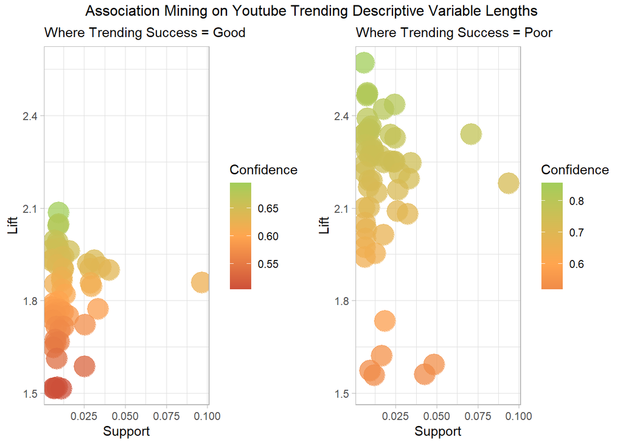

```r
am_plot(length_overall_success, inverse.length_overall_success,"Trending Success", "Good", "Poor", "Descriptive Variable Lengths")
```

```r
Good.rules_table <- bind_rows(Good.rules_table, length_overall_success,)
Poor.rules_table <- bind_rows(Poor.rules_table, inverse.length_overall_success)
```

Trending Speed:

```r
length_speed_success <- length_mining("days_until_trending_category", "Good")
inverse.length_speed_success <- length_mining("days_until_trending_category", "Poor")
```

```r
print(length_speed_success)
```

```
## [1] "There are no rules for this metric"
```

```r
print(inverse.length_speed_success)
```

```
## [1] "There are no rules for this metric"
```

Trending Retention:

```r
length_retention_success <- length_mining("trending_retention_category", "Good")
inverse.length_retention_success <- length_mining("trending_retention_category", "Poor")
```

```r
print(length_retention_success)
```

```
## [1] "There are no rules for this metric"
```

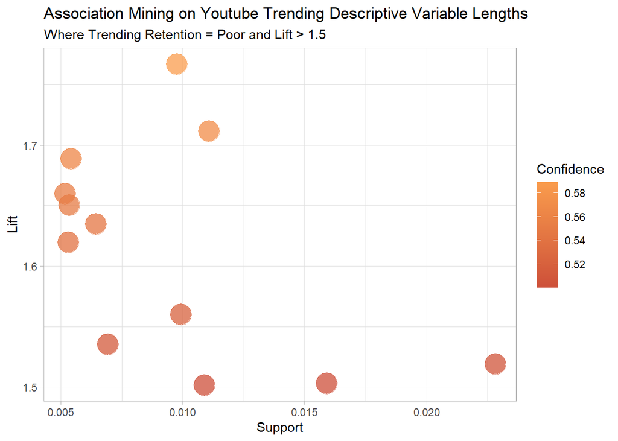

```r
ggplot(inverse.length_retention_success, aes(x = support, y = lift, color = confidence)) +
    geom_point(size = 8, alpha = 0.75) +  # Adjusted size for better visualization
    scale_color_gradient2(low = "tomato3", mid = "tan1", high = "darkolivegreen3",
                          midpoint = 0.6, name = "Confidence") +
    theme_light() +
    labs(
      title = "Association Mining on Youtube Trending Descriptive Variable Lengths",
      x = "Support",
      y = "Lift",
      subtitle = paste("Where Trending Retention = Poor and Lift > 1.5"))
```

```r
Poor.rules_table <- bind_rows(Poor.rules_table, inverse.length_retention_success)
```

Engagement Ratio:

```r
length_engage_success <- length_mining("engagement_ratio_category", "Good")
inverse.length_engage_success <- length_mining("engagement_ratio_category", "Poor")
```

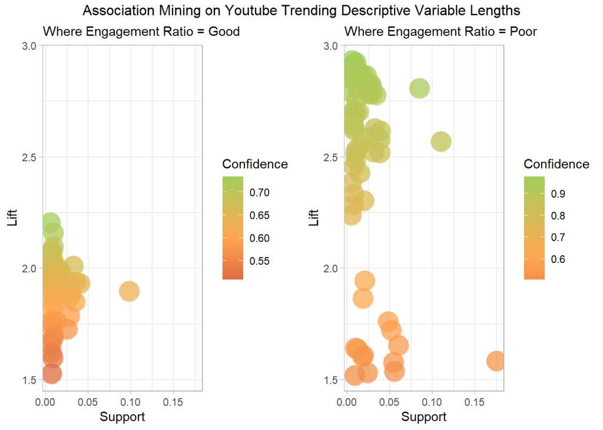

```r
am_plot(length_engage_success, inverse.length_engage_success,"Engagement Ratio", "Good", "Poor", "Descriptive Variable Lengths")
```

```r
Good.rules_table <- bind_rows(Good.rules_table, length_engage_success)
Poor.rules_table <- bind_rows(Poor.rules_table, inverse.length_engage_success)
```

Final Rules Table for Descriptive Variable Lengths

```r
length_rules_good <- Good.rules_table
length_rules_poor <- Poor.rules_table

length_rules_good <- clean_rules_tables(length_rules_good)
length_rules_poor <- clean_rules_tables(length_rules_poor)

mean(length_rules_good$confidence)
```

```
## [1] 0.7270231
```

```r
mean(length_rules_poor$confidence)
```

```
## [1] 0.8883277
```

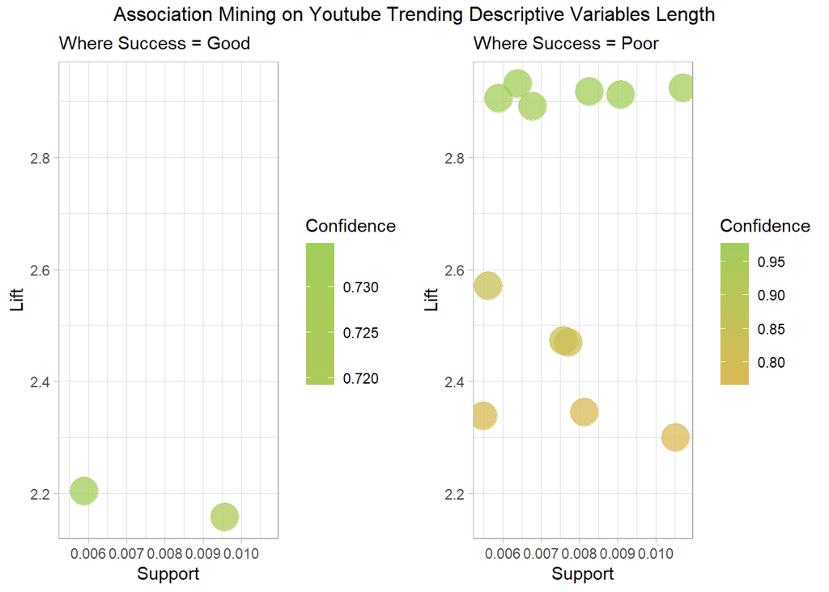

Length of Descriptive Varibales *Good* Success Rules

| rules | support | confidence | coverage | lift | count | category | metric |
| --- | --- | --- | --- | --- | --- | --- | --- |
| {category_name=Comedy,tag_usage_category=Low,title_length_category=Short} => {engagement_ratio_category=Good} | 0.0058781 | 0.7347480 | 0.0080002 | 2.204244 | 277 | Comedy | engagement_ratio_category |
| {category_name=Music,title_length_category=Short,description_length_category=Long} => {engagement_ratio_category=Good} | 0.0095705 | 0.7192982 | 0.0133053 | 2.157895 | 451 | Music | engagement_ratio_category |

Length of Descriptive Variables *Poor* Success Rules

| rules | support | confidence | coverage | lift | count | category | metric |
| --- | --- | --- | --- | --- | --- | --- | --- |
| {category_name=News & Politics,title_length_category=Long,description_length_category=Mid} => {engagement_ratio_category=Poor} | 0.0082548 | 0.9725000 | 0.0084882 | 2.917500 | 389 | News & Politics | engagement_ratio_category |
| {category_name=News & Politics,tag_usage_category=Low,description_length_category=Mid} => {engagement_ratio_category=Poor} | 0.0058781 | 0.9685315 | 0.0060691 | 2.905594 | 277 | News & Politics | engagement_ratio_category |
| {category_name=News & Politics,tag_usage_category=Low,title_length_category=Long,description_length_category=Short} => {engagement_ratio_category=Poor} | 0.0067694 | 0.9637462 | 0.0070240 | 2.891239 | 319 | News & Politics | engagement_ratio_category |
| {category_name=News & Politics,tag_usage_category=Low,description_length_category=Short} => {overall_success=Poor} | 0.0081275 | 0.7816327 | 0.0103981 | 2.344898 | 383 | News & Politics | overall_success |
| {category_name=News & Politics,tag_usage_category=Low,title_length_category=Long,description_length_category=Short} => {overall_success=Poor} | 0.0054749 | 0.7794562 | 0.0070240 | 2.338369 | 258 | News & Politics | overall_success |
| {category_name=News & Politics,tag_usage_category=Low,title_length_category=Long} => {overall_success=Poor} | 0.0105254 | 0.7666151 | 0.0137297 | 2.299845 | 496 | News & Politics | overall_success |
| {category_name=Sports,tag_usage_category=No Tags Used,title_length_category=Long,description_length_category=Short} => {engagement_ratio_category=Poor} | 0.0063874 | 0.9772727 | 0.0065359 | 2.931818 | 301 | Sports | engagement_ratio_category |
| {category_name=Sports,tag_usage_category=Mid,title_length_category=Long,description_length_category=Long} => {engagement_ratio_category=Poor} | 0.0107164 | 0.9749035 | 0.0109923 | 2.924710 | 505 | Sports | engagement_ratio_category |
| {category_name=Sports,tag_usage_category=Low,title_length_category=Long,description_length_category=Mid} => {engagement_ratio_category=Poor} | 0.0090824 | 0.9705215 | 0.0093583 | 2.911565 | 428 | Sports | engagement_ratio_category |
| {category_name=Sports,tag_usage_category=No Tags Used,title_length_category=Long,description_length_category=Short} => {overall_success=Poor} | 0.0056022 | 0.8571429 | 0.0065359 | 2.571429 | 264 | Sports | overall_success |
| {category_name=Sports,tag_usage_category=Low,title_length_category=Long,description_length_category=Short} => {overall_success=Poor} | 0.0075758 | 0.8244804 | 0.0091885 | 2.473441 | 357 | Sports | overall_success |
| {category_name=Sports,tag_usage_category=Low,title_length_category=Long,description_length_category=Mid} => {overall_success=Poor} | 0.0077031 | 0.8231293 | 0.0093583 | 2.469388 | 363 | Sports | overall_success |

[output not shown]

## Section 3.3: Published Timing Associations

Are videos published at specific times (Times of day, times of week, times of month, times of year) associated with better success metrics?

Data Prep and Function Creation:

```r
# Reinitialize the rules tables as empty data frames
Good.rules_table <- data.frame(
  rules =character(),
  support = numeric(),
  confidence = numeric(),
  coverage = numeric(),
  lift = numeric(),
  count = integer()
)[0, ]

Poor.rules_table <- data.frame(
  rules =character(),
  support = numeric(),
  confidence = numeric(),
  coverage = numeric(),
  lift = numeric(),
  count = integer()
)[0, ]

am.2_df <- arules_df %>%
  mutate(
    # Recode timestamp into descriptive labels
    time_of_day = case_when(
      hour(date_published) >= 0 & hour(date_published) < 6 ~"Night",
      hour(date_published) >= 6 & hour(date_published) < 12 ~ "Morning",
      hour(date_published) >= 12 & hour(date_published) < 18 ~ "Afternoon",
      hour(date_published) >= 18 ~ "Evening"),

    # Recode the Date into descriptive labels, such as day-of-week, time of month, and season
    time_of_week = wday(date_published, label = TRUE, abbr = FALSE),

    time_of_month = case_when(
      ceiling(day(date_published) / 7) == 1 ~ "Beginning",
      (ceiling(day(date_published) / 7 ) == 2 |
         ceiling(day(date_published) / 7 ) == 3) ~ "Middle",
      ceiling(day(date_published) / 7 ) >= 4 ~ "End"),

    time_of_year = case_when(
      month(date_published, label = TRUE, abbr = FALSE) %in% c(
        "March", "April", "May") ~ "Spring",
      month(date_published, label = TRUE, abbr = FALSE) %in% c(
        "June", "July", "August") ~ "Summer",
    month(date_published, label = TRUE, abbr = FALSE) %in% c(
      "September", "October", "November") ~ "Autumn",
    month(date_published, label = TRUE, abbr = FALSE) %in% c(
      "December", "January", "February") ~ "Winter")
  ) %>%
  select(category_name, time_of_day, time_of_week, time_of_month, time_of_year, overall_success, days_until_trending_category, trending_retention_category, engagement_ratio_category)


time_mining <- function(metric, eval) {
  df <-  am.2_df %>%
    select(category_name, time_of_day, time_of_week, time_of_month, time_of_year, metric)

  # Convert the data frame into a transactions object
  transactions <- as(df, "transactions")

  rhs = paste0(metric, "=", eval)

  # Generate association rules using the apriori algorithm
  rules <- apriori(
    transactions,
    parameter = list(support = 0.005, confidence = 0.5),
    appearance = list(default = "lhs", rhs = rhs)
  )

  if (length(rules) == 0) {
    return("There are no rules for this metric")
  }

  # Convert rules to data frame, filter by lift > 2, and arrange them by descending lift
  rules_df <- as(rules, "data.frame") %>%
    filter(lift > 1.5) %>%
    arrange(desc(lift))

  if (nrow(rules_df) == 0) {
    return("There are no rules with a lift higher than 2 for this metric")
  }

  return(rules_df)
}
```

Overall Success:

```r
overall_success_rules <- time_mining("overall_success", "Good")
inverse_success_rules <- time_mining("overall_success", "Poor")
```

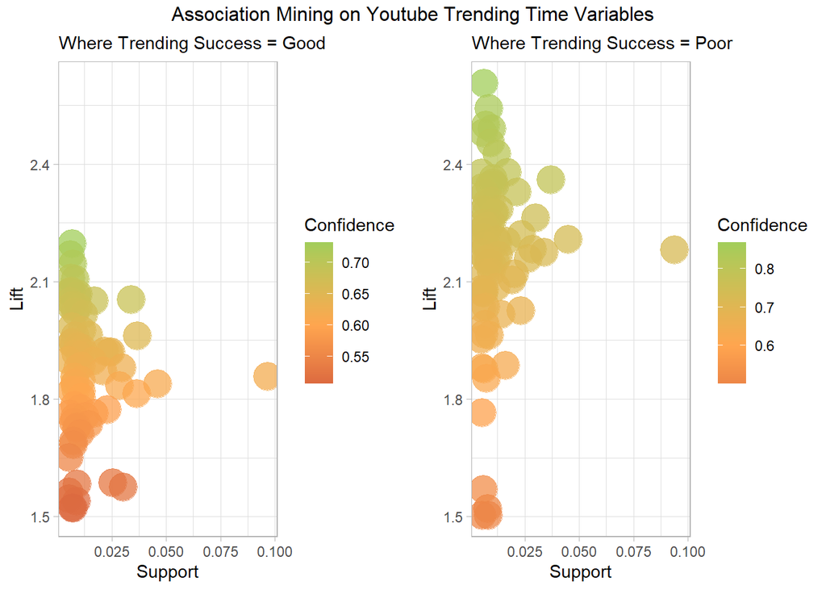

```r
am_plot(overall_success_rules, inverse_success_rules,"Trending Success", "Good", "Poor", "Time Variables")
```

```r
Good.rules_table <- bind_rows(Good.rules_table, overall_success_rules)
Poor.rules_table <- bind_rows(Poor.rules_table, inverse_success_rules)
```

Trending Speed:

```r
days.until_success_rules <- time_mining("days_until_trending_category", "Good")
inverse_days.until_srules <- time_mining("days_until_trending_category", "Poor")
```

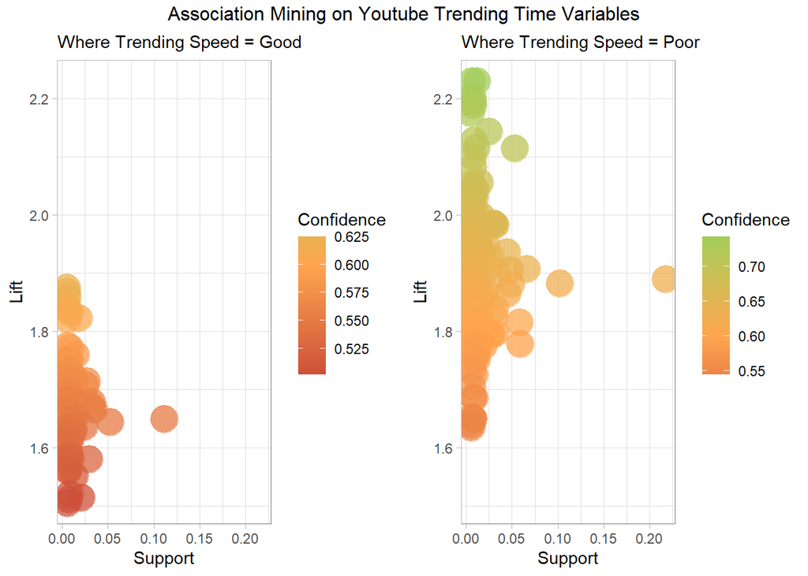

```r
am_plot(days.until_success_rules, inverse_days.until_srules,"Trending Speed", "Good", "Poor", "Time Variables")
```

```r
Good.rules_table <- bind_rows(Good.rules_table, days.until_success_rules)
Poor.rules_table <- bind_rows(Poor.rules_table, inverse_days.until_srules)
```

Trending Retention:

```r
retention_success_rules <- time_mining("trending_retention_category", "Good")
inverse_retention_success_rules <- time_mining("trending_retention_category", "Poor")
```

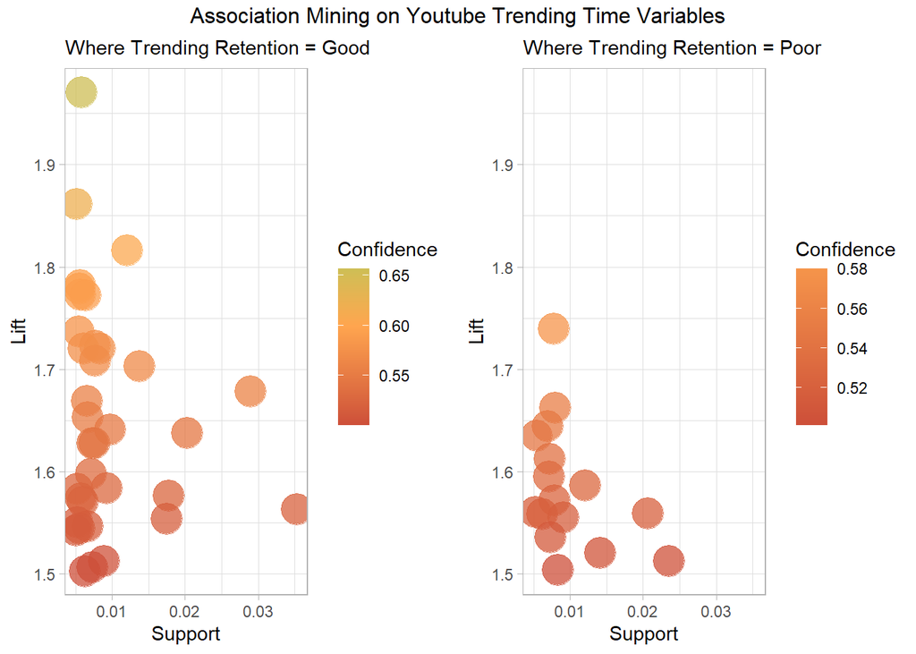

```r
am_plot(retention_success_rules, inverse_retention_success_rules,"Trending Retention", "Good", "Poor", "Time Variables")
```

```r
Good.rules_table <- bind_rows(Good.rules_table, retention_success_rules)
Poor.rules_table <- bind_rows(Poor.rules_table, inverse_retention_success_rules)
```

Engagement Ratio:

```r
engagement_success_rules <- time_mining("engagement_ratio_category", "Good")
inverse_engagement_rules <- time_mining("engagement_ratio_category", "Poor")
```

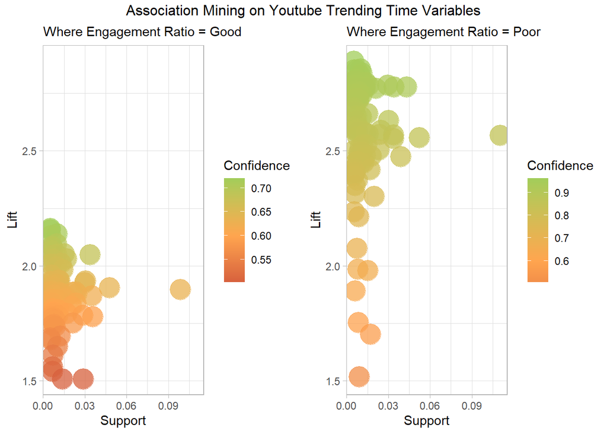

```r
am_plot(engagement_success_rules, inverse_engagement_rules,"Engagement Ratio", "Good", "Poor", "Time Variables")
```

```r
Good.rules_table <- bind_rows(Good.rules_table, engagement_success_rules)
Poor.rules_table <- bind_rows(Poor.rules_table, inverse_engagement_rules)
```

Final Rules Table for Publishing Time:

```r
time_rules_good <- Good.rules_table
time_rules_poor <- Poor.rules_table

time_rules_good <- clean_rules_tables(time_rules_good)
time_rules_poor <- clean_rules_tables(time_rules_poor)

mean(time_rules_good$confidence)
```

```
## [1] 0.7190218
```

```r
mean(time_rules_poor$confidence)
```

```
## [1] 0.8303794
```

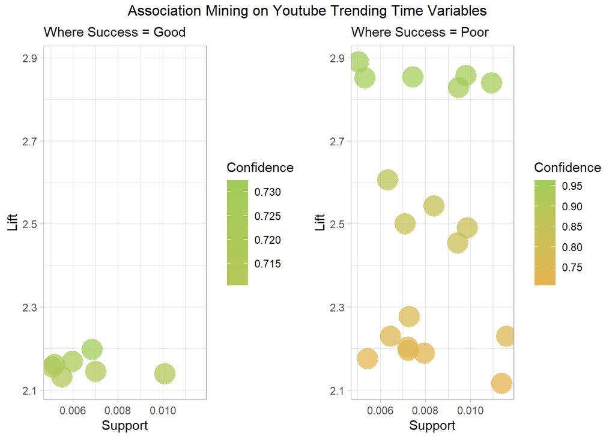

Time Varibales *Good* Success Rules

| rules | support | confidence | coverage | lift | count | category | metric |
| --- | --- | --- | --- | --- | --- | --- | --- |
| {category_name=Comedy,time_of_day=Evening,time_of_month=End} => {engagement_ratio_category=Good} | 0.0050929 | 0.7185629 | 0.0070877 | 2.155689 | 240 | Comedy | engagement_ratio_category |
| {category_name=Music,time_of_day=Afternoon,time_of_year=Winter} => {overall_success=Good} | 0.0068543 | 0.7324263 | 0.0093583 | 2.197279 | 323 | Music | overall_success |
| {category_name=Music,time_of_month=End,time_of_year=Winter} => {overall_success=Good} | 0.0059842 | 0.7230769 | 0.0082760 | 2.169231 | 282 | Music | overall_success |
| {category_name=Music,time_of_day=Afternoon,time_of_month=Middle,time_of_year=Summer} => {engagement_ratio_category=Good} | 0.0051990 | 0.7205882 | 0.0072150 | 2.161765 | 245 | Music | engagement_ratio_category |
| {category_name=Music,time_of_day=Afternoon,time_of_week=Wednesday} => {overall_success=Good} | 0.0070240 | 0.7149028 | 0.0098251 | 2.144708 | 331 | Music | overall_success |
| {category_name=Music,time_of_day=Afternoon,time_of_year=Summer} => {engagement_ratio_category=Good} | 0.0100798 | 0.7132132 | 0.0141329 | 2.139640 | 475 | Music | engagement_ratio_category |
| {category_name=Music,time_of_day=Afternoon,time_of_week=Tuesday} => {engagement_ratio_category=Good} | 0.0055174 | 0.7103825 | 0.0077667 | 2.131147 | 260 | Music | engagement_ratio_category |

Time Variables *Poor* Success Rules

| rules | support | confidence | coverage | lift | count | category | metric |
| --- | --- | --- | --- | --- | --- | --- | --- |
| {category_name=Gaming,time_of_day=Evening,time_of_month=Middle,time_of_year=Summer} => {days_until_trending_category=Poor} | 0.0054325 | 0.7252125 | 0.0074909 | 2.175637 | 256 | Gaming | days_until_trending_category |
| {category_name=Gaming,time_of_day=Evening,time_of_year=Summer} => {days_until_trending_category=Poor} | 0.0113742 | 0.7052632 | 0.0161277 | 2.115789 | 536 | Gaming | days_until_trending_category |
| {category_name=News & Politics,time_of_day=Evening,time_of_month=Middle} => {engagement_ratio_category=Poor} | 0.0053264 | 0.9507576 | 0.0056022 | 2.852273 | 251 | News & Politics | engagement_ratio_category |
| {category_name=News & Politics,time_of_day=Evening} => {engagement_ratio_category=Poor} | 0.0109286 | 0.9466912 | 0.0115440 | 2.840073 | 515 | News & Politics | engagement_ratio_category |
| {category_name=News & Politics,time_of_day=Night} => {engagement_ratio_category=Poor} | 0.0094644 | 0.9429175 | 0.0100373 | 2.828753 | 446 | News & Politics | engagement_ratio_category |
| {category_name=News & Politics,time_of_year=Summer} => {overall_success=Poor} | 0.0071089 | 0.8333333 | 0.0085307 | 2.500000 | 335 | News & Politics | overall_success |
| {category_name=News & Politics,time_of_day=Evening} => {overall_success=Poor} | 0.0094432 | 0.8180147 | 0.0115440 | 2.454044 | 445 | News & Politics | overall_success |
| {category_name=News & Politics,time_of_year=Autumn} => {overall_success=Poor} | 0.0072787 | 0.7588496 | 0.0095917 | 2.276549 | 343 | News & Politics | overall_success |
| {category_name=People & Blogs,time_of_day=Evening,time_of_year=Summer} => {days_until_trending_category=Poor} | 0.0064511 | 0.7432763 | 0.0086792 | 2.229829 | 304 | People & Blogs | days_until_trending_category |
| {category_name=Sports,time_of_day=Night,time_of_week=Sunday,time_of_month=Middle} => {engagement_ratio_category=Poor} | 0.0050293 | 0.9634146 | 0.0052203 | 2.890244 | 237 | Sports | engagement_ratio_category |
| {category_name=Sports,time_of_day=Night,time_of_week=Sunday} => {engagement_ratio_category=Poor} | 0.0098039 | 0.9525773 | 0.0102920 | 2.857732 | 462 | Sports | engagement_ratio_category |
| {category_name=Sports,time_of_week=Sunday,time_of_year=Winter} => {engagement_ratio_category=Poor} | 0.0074484 | 0.9512195 | 0.0078304 | 2.853658 | 351 | Sports | engagement_ratio_category |
| {category_name=Sports,time_of_day=Evening,time_of_week=Saturday} => {overall_success=Poor} | 0.0063237 | 0.8688047 | 0.0072787 | 2.606414 | 298 | Sports | overall_success |
| {category_name=Sports,time_of_day=Evening,time_of_year=Summer} => {overall_success=Poor} | 0.0083821 | 0.8476395 | 0.0098888 | 2.542918 | 395 | Sports | overall_success |
| {category_name=Sports,time_of_day=Evening,time_of_week=Sunday} => {overall_success=Poor} | 0.0098676 | 0.8303571 | 0.0118835 | 2.491071 | 465 | Sports | overall_success |
| {category_name=Sports,time_of_day=Evening,time_of_year=Summer} => {days_until_trending_category=Poor} | 0.0072362 | 0.7317597 | 0.0098888 | 2.195279 | 341 | Sports | days_until_trending_category |
| {time_of_day=Evening,time_of_month=Beginning,time_of_year=Summer} => {days_until_trending_category=Poor} | 0.0116077 | 0.7432065 | 0.0156184 | 2.229620 | 547 | NA | days_until_trending_category |
| {time_of_day=Evening,time_of_week=Friday,time_of_year=Summer} => {days_until_trending_category=Poor} | 0.0072150 | 0.7343413 | 0.0098251 | 2.203024 | 340 | NA | days_until_trending_category |
| {time_of_day=Evening,time_of_week=Thursday,time_of_year=Summer} => {days_until_trending_category=Poor} | 0.0079577 | 0.7295720 | 0.0109074 | 2.188716 | 375 | NA | days_until_trending_category |

[output not shown]

## Section 3.4: Dominant Sentiments Associations

Are videos of certain sentiments associated with better success metrics across different channel categories?

Data Prep and Function Creation:

```r
# Reinitialize the rules tables as empty data frames
Good.rules_table <- data.frame(
  rules =character(),
  support = numeric(),
  confidence = numeric(),
  coverage = numeric(),
  lift = numeric(),
  count = integer()
)[0, ]

Poor.rules_table <- data.frame(
  rules =character(),
  support = numeric(),
  confidence = numeric(),
  coverage = numeric(),
  lift = numeric(),
  count = integer()
)[0, ]

# No Recoding Required as Dominant Sentiments is already a categorical factor
sentiment_mining <- function(metric, eval) {
  df <-  arules_df %>%
    select(category_name, dominant_sentiment, metric)

  # Convert the data frame into a transactions object
  transactions <- as(df, "transactions")

  rhs = paste0(metric, "=", eval)

  # Generate association rules using the apriori algorithm
  rules <- apriori(
    transactions,
    parameter = list(support = 0.005, confidence = 0.5),
    appearance = list(default = "lhs", rhs = rhs)
  )

  if (length(rules) == 0) {
    return("There are no rules for this metric")
  }

  # Convert rules to data frame, filter by lift > 2, and arrange them by descending lift
  rules_df <- as(rules, "data.frame") %>%
    filter(lift > 1.5) %>%
    arrange(desc(lift))

  if (nrow(rules_df) == 0) {
    return("There are no rules with a lift higher than 2 for this metric")
  }

  return(rules_df)
}
```

Overall Success:

```r
sentiment_overall_rules <- sentiment_mining("overall_success", "Good")
inverse.sentiment_overall_rules <- sentiment_mining("overall_success", "Poor")
```

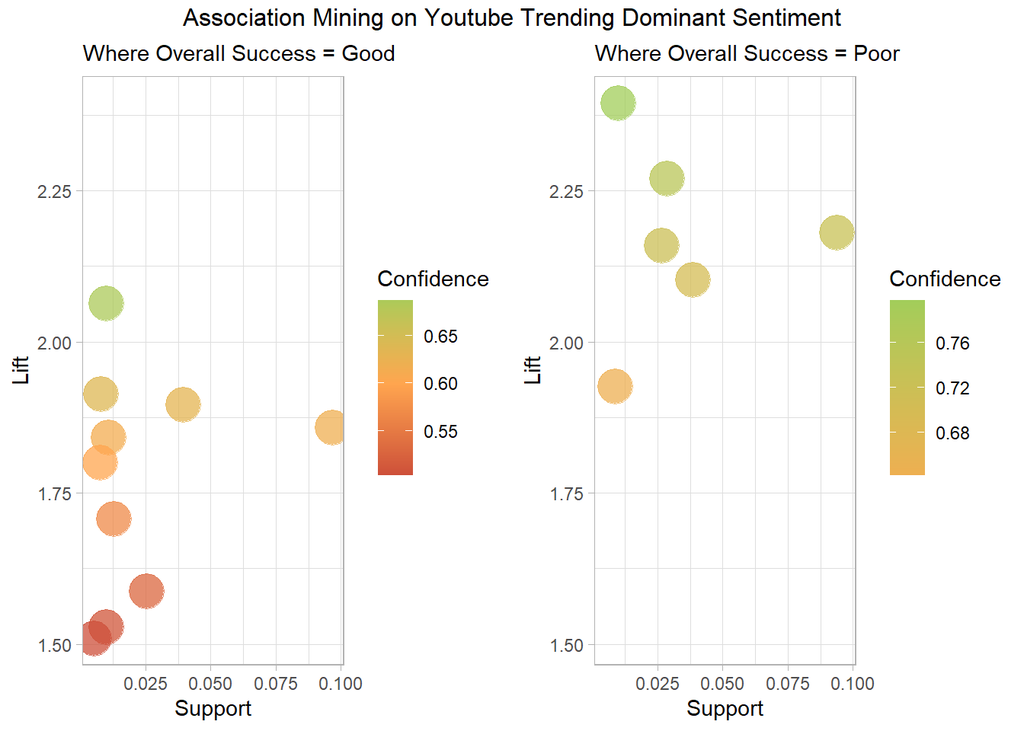

```r
am_plot(sentiment_overall_rules, inverse.sentiment_overall_rules,"Overall Success", "Good", "Poor", "Dominant Sentiment")
```

```r
Good.rules_table <- bind_rows(Good.rules_table, sentiment_overall_rules)
Poor.rules_table <- bind_rows(Poor.rules_table, inverse.sentiment_overall_rules)
```

Trending Speed:

```r
sentiment_speed_rules <- sentiment_mining("days_until_trending_category", "Good")
inverse.sentiment_speed_rules <- sentiment_mining("days_until_trending_category", "Poor")
```

```r
print(sentiment_speed_rules)
```

```
## [1] "There are no rules for this metric"
```

```r
print(inverse.sentiment_speed_rules)
```

```
## [1] "There are no rules for this metric"
```

Trending Retention:

```r
sentiment_retention_rules <- sentiment_mining("trending_retention_category", "Good")
inverse.sentiment_retention_rules <- sentiment_mining("trending_retention_category", "Poor")
```

```r
print(sentiment_retention_rules)
```

```
## [1] "There are no rules for this metric"
```

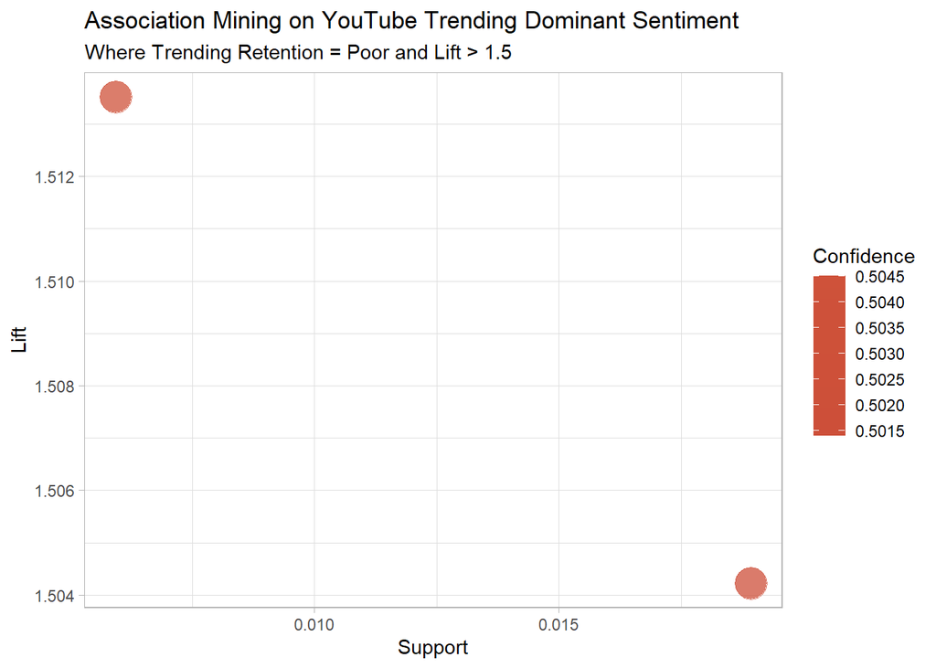

```r
ggplot(inverse.sentiment_retention_rules, aes(x = support, y = lift, color = confidence)) +
    geom_point(size = 8, alpha = 0.75) +  # Adjusted size for better visualization
    scale_color_gradient2(low = "tomato3", mid = "tan1", high = "darkolivegreen3",
                          midpoint = 0.6, name = "Confidence") +
    theme_light() +
    labs(
      title = "Association Mining on YouTube Trending Dominant Sentiment",
      x = "Support",
      y = "Lift",
      subtitle = paste("Where Trending Retention = Poor and Lift > 1.5"))
```

```r
Poor.rules_table <- bind_rows(Poor.rules_table, inverse.sentiment_retention_rules)
```

Engagement Ratio:

```r
sentiment_engage_rules <- sentiment_mining("engagement_ratio_category", "Good")
inverse.sentiment_engage_rules <- sentiment_mining("engagement_ratio_category", "Poor")
```

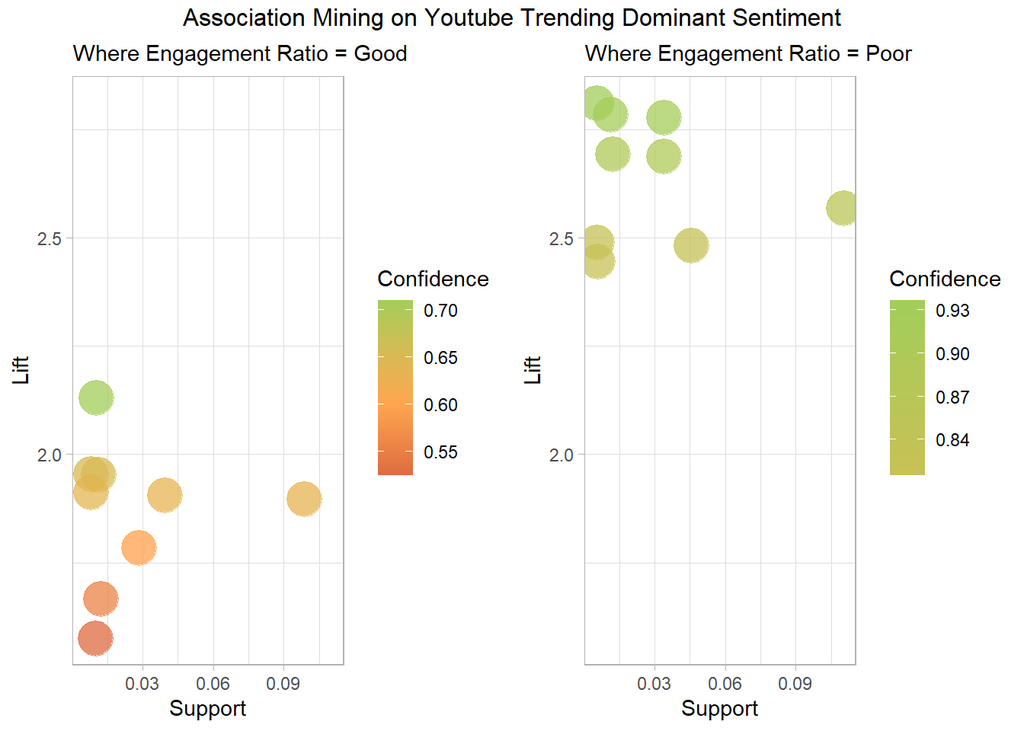

```r
am_plot(sentiment_engage_rules, inverse.sentiment_engage_rules,"Engagement Ratio", "Good", "Poor", "Dominant Sentiment")
```

```r
Good.rules_table <- bind_rows(Good.rules_table, sentiment_engage_rules)
Poor.rules_table <- bind_rows(Poor.rules_table, inverse.sentiment_engage_rules)
```

Final Rules Table for Dominant Sentiment

```r
sentiment_rules_good <- Good.rules_table
sentiment_rules_poor <- Poor.rules_table

sentiment_rules_good <- clean_rules_tables(sentiment_rules_good)
sentiment_rules_poor <- clean_rules_tables(sentiment_rules_poor)

mean(sentiment_rules_good$confidence)
```

```
## [1] 0.7102526
```

```r
mean(sentiment_rules_poor$confidence)
```

```
## [1] 0.8442663
```

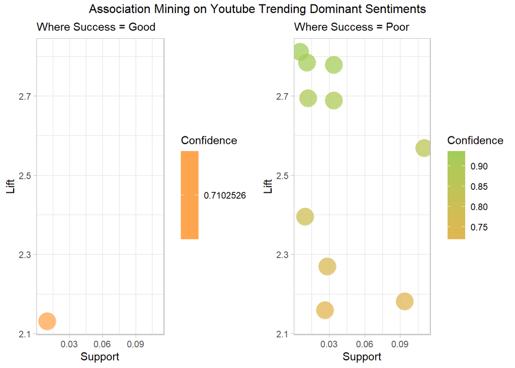

Dominant Sentiment *Good* Success Rules

| rules | support | confidence | coverage | lift | count | category | metric |
| --- | --- | --- | --- | --- | --- | --- | --- |
| {category_name=Music,dominant_sentiment=trust} => {engagement_ratio_category=Good} | 0.0101435 | 0.7102526 | 0.0142815 | 2.130758 | 478 | Music | engagement_ratio_category |

Dominant Sentiment *Poor* Success Rules

| rules | support | confidence | coverage | lift | count | category | metric |
| --- | --- | --- | --- | --- | --- | --- | --- |
| {category_name=News & Politics,dominant_sentiment=anticipation} => {engagement_ratio_category=Poor} | 0.0053688 | 0.9370370 | 0.0057296 | 2.811111 | 253 | News & Politics | engagement_ratio_category |
| {category_name=News & Politics} => {engagement_ratio_category=Poor} | 0.0339954 | 0.9260116 | 0.0367117 | 2.778035 | 1602 | News & Politics | engagement_ratio_category |
| {category_name=News & Politics,dominant_sentiment=positive} => {engagement_ratio_category=Poor} | 0.0121382 | 0.8979592 | 0.0135175 | 2.693878 | 572 | News & Politics | engagement_ratio_category |
| {category_name=News & Politics} => {overall_success=Poor} | 0.0264197 | 0.7196532 | 0.0367117 | 2.158959 | 1245 | News & Politics | overall_success |
| {category_name=Sports,dominant_sentiment=trust} => {engagement_ratio_category=Poor} | 0.0112257 | 0.9280702 | 0.0120957 | 2.784210 | 529 | Sports | engagement_ratio_category |
| {category_name=Sports,dominant_sentiment=anticipation} => {engagement_ratio_category=Poor} | 0.0338257 | 0.8960090 | 0.0377515 | 2.688027 | 1594 | Sports | engagement_ratio_category |
| {category_name=Sports} => {engagement_ratio_category=Poor} | 0.1103259 | 0.8560843 | 0.1288728 | 2.568253 | 5199 | Sports | engagement_ratio_category |
| {category_name=Sports,dominant_sentiment=trust} => {overall_success=Poor} | 0.0096554 | 0.7982456 | 0.0120957 | 2.394737 | 455 | Sports | overall_success |
| {category_name=Sports,dominant_sentiment=anticipation} => {overall_success=Poor} | 0.0285629 | 0.7566048 | 0.0377515 | 2.269814 | 1346 | Sports | overall_success |
| {category_name=Sports} => {overall_success=Poor} | 0.0936890 | 0.7269883 | 0.1288728 | 2.180965 | 4415 | Sports | overall_success |

[output not shown]

## Section 3.6: Final Association Rules

```r
Good.rules_table <- rbind(length_rules_good, time_rules_good, sentiment_rules_good)
Poor.rules_table <- rbind(length_rules_poor, time_rules_poor, sentiment_rules_poor)

mean(Good.rules_table$confidence)
```

```
## [1] 0.7197452
```

```r
mean(Poor.rules_table$confidence)
```

```
## [1] 0.8507269
```

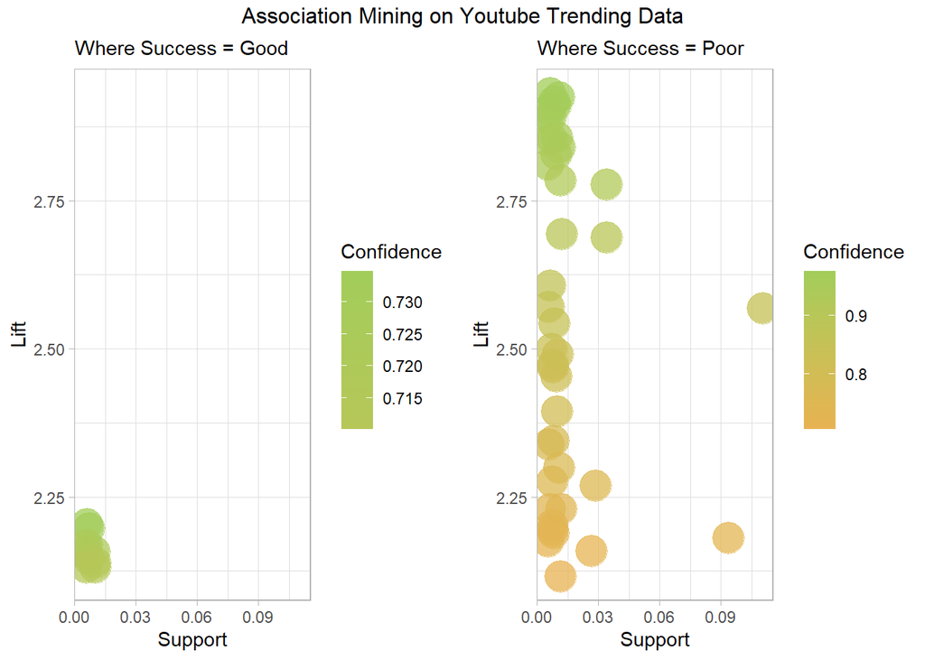

[output not shown]

```r
# Plotting Final Association Rules Tables
am_plot(Good.rules_table, Poor.rules_table,"Success", "Good", "Poor", "Data")
```

## Conclusions

What are our final recommendations to YouTube Creators based on our the descriptive statistics of our dataset, our sentiment analysis, and our association mining?

[output not shown]

Limitations:

[output not shown]